# Statistical Inference

Weeks 1–2 · 2026 · Probability models, distributions, and convergence

## What is statistical inference?

STATISTICAL INFERENCE ● WEEKS 1–2

Statistical inference is the process of using data from a small sample to draw conclusions or make generalizations about a larger population.

[figure not shown]

Typically, we assume that our data follows a probability distribution, and we try to learn properties of the underlying distribution (mean, variance, covariances, other parameters...) by estimation, in order to make predictions about the population from the sample.

## Statistical inference is the foundation of all empirical disciplines.

STATISTICAL INFERENCE ● WEEKS 1–2

“Since all models are wrong the scientist must be alert to what is importantly wrong.”

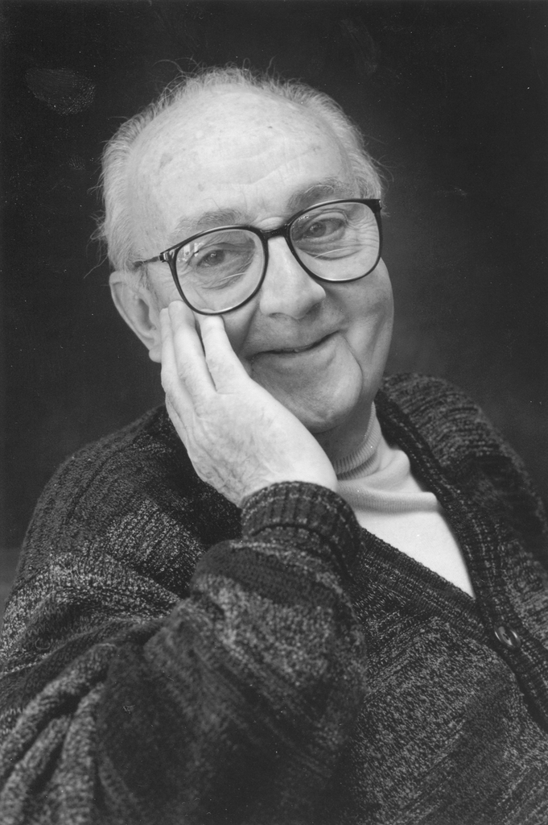

— George E. P. Box  
[Science and Statistics (1976), p. 792](https://gwern.net/doc/statistics/decision/1976-box.pdf#page=2)

Photo: [DavidMCEddy](https://commons.wikimedia.org/wiki/File:GeorgeEPBox.jpg) · [CC BY-SA 3.0](https://creativecommons.org/licenses/by-sa/3.0/)

[figure not shown]

## Primer: assignments and exams

STATISTICAL INFERENCE ● WEEKS 1–2

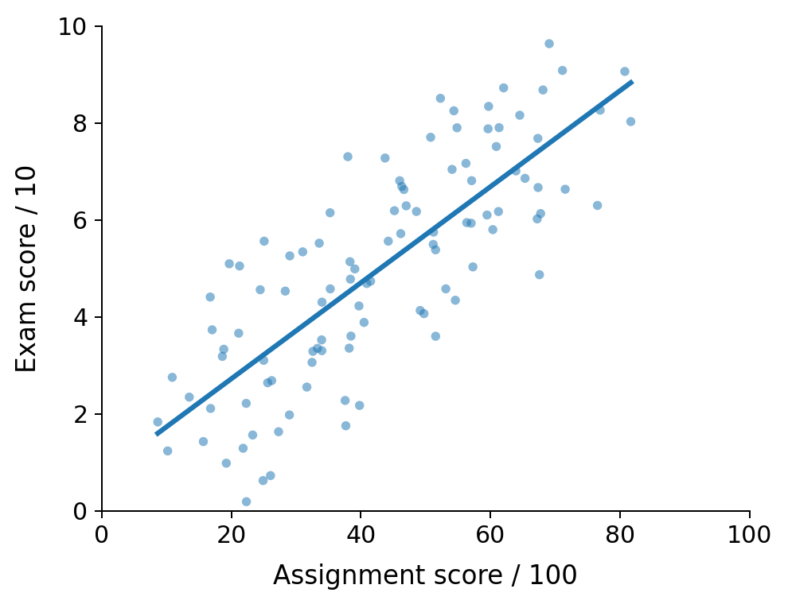

2020

$n=104$ synthetic observations

Slope $\widehat\beta$**0.099**

Correlation $r$**0.79**

High correlation.

Assignment grades predict exam grades.

Synthetic data. Inspired by T. Osborne, QuSoft (2026).

## Assignments and exams

STATISTICAL INFERENCE ● WEEKS 1–2

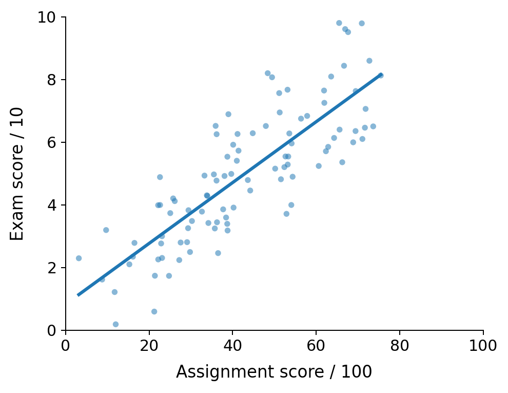

2021

$n=98$ synthetic observations

Slope $\widehat\beta$**0.097**

Correlation $r$**0.82**

A similar pattern appears again.

Is there a causal relationship between assignment grades and exam grades?

Synthetic data. Inspired by T. Osborne, QuSoft (2026).

## Assignments and exams

STATISTICAL INFERENCE ● WEEKS 1–2

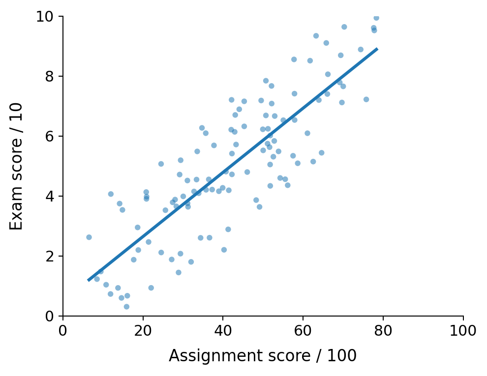

2022

$n=112$ synthetic observations

Slope $\widehat\beta$**0.107**

Correlation $r$**0.84**

Still the same.

Maybe there is some kind of law of nature saying that when you are doing well in the assignments you are also doing well in the exams?

Synthetic data. Inspired by T. Osborne, QuSoft (2026).

## Assignments and exams

STATISTICAL INFERENCE ● WEEKS 1–2

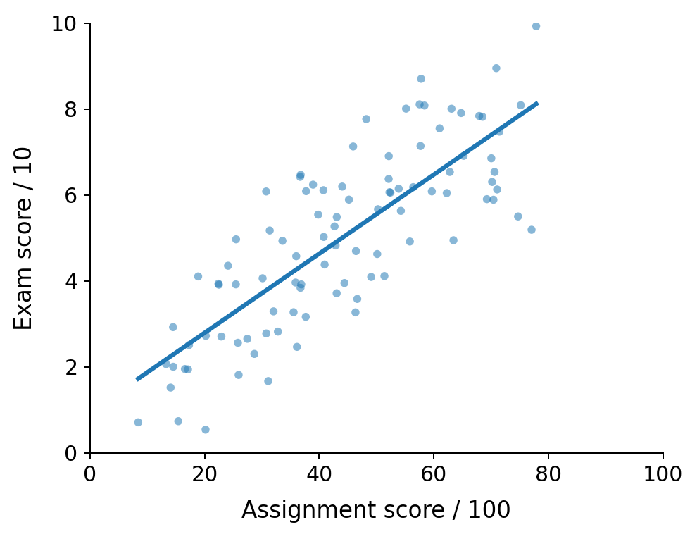

2023

$n=96$ synthetic observations

Slope $\widehat\beta$**0.092**

Correlation $r$**0.80**

The positive correlation is still visible.

How could this possibly ever change?

Synthetic data. Inspired by T. Osborne, QuSoft (2026).

## Assignments and exams

STATISTICAL INFERENCE ● WEEKS 1–2

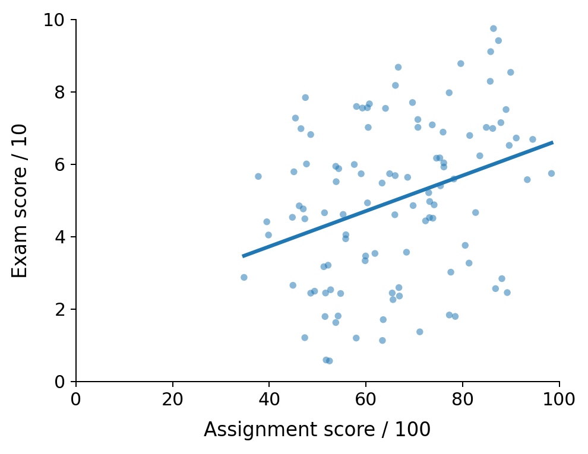

2024

$n=108$ synthetic observations

Slope $\widehat\beta$**0.049**

Correlation $r$**0.33**

What happened here?

The line is flatter. The correlation is weaker. Assignment scores have shifted upwards.

Synthetic data. Inspired by T. Osborne, QuSoft (2026).

## Assignments and exams

STATISTICAL INFERENCE ● WEEKS 1–2

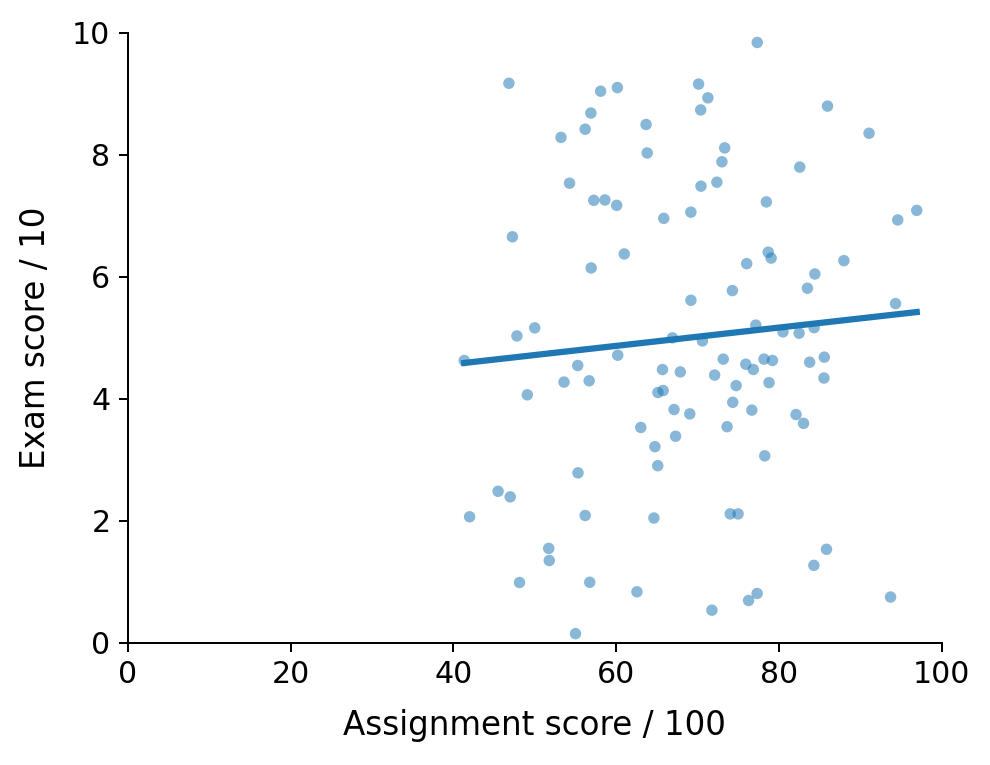

2025

$n=101$ synthetic observations

Slope $\widehat\beta$**0.015**

Correlation $r$**0.08**

Almost no linear correlation remains.

Does the assignment still measure what the exam measures?

Synthetic data. Inspired by T. Osborne, QuSoft (2026).

## Course scope and assessment

STATISTICAL INFERENCE ● WEEKS 1–2

A

### Probability theory

Random variables, distributions, convergence, limit theorems

B

### Nonparametric models

Estimation, goodness of fit, ranks, association

C

### Parametric models

Sufficiency, likelihood, estimation, tests

D

### Bayesian statistics

Priors, posteriors, conjugacy, Bayes estimators

Assessment · 2026/27

**Exam: 100%**

Old · [2025/2026](https://sigarra.up.pt/fcup/en/ucurr_geral.ficha_uc_view?pv_ocorrencia_id=570089) · No longer applicable

**Exam 60% · Project/presentation 25% · Written report 15%**

## Weeks 1–2: the first four lectures

STATISTICAL INFERENCE ● WEEKS 1–2

### Scalar distributions

Probability spaces, random elements, probability distribution functions, quantiles, densities

### Random vectors

Joint distributions, conditioning, generated σ-algebras, independence

### Descriptive statistics

Expected values, moments, covariance, standard families, transforms

### Convergence

Almost sure, $L^\infty$, probability, $L^p$, distribution

# Probability spaces and scalar distributions

STATISTICAL INFERENCE ● WEEKS 1–2

01 · WEEK 1 · LECTURE 1

Probability spaces, random elements, probability distribution functions, and quantiles.

## A brief history of probability theory

STATISTICAL INFERENCE ● WEEKS 1–2

4th c. BCE

**Aristotle:** probability is not part of mathematics. Mathematics describes what is logically necessary, whereas probability reasons about what is plausible. Predominant view until the 17th century.

1654

**Blaise Pascal and Pierre de Fermat** lay foundations for mathematical probability in their correspondence on gambling problems.

1898–1902

**Émile Borel and Henri Lebesgue** invent $\sigma$-algebrae and measure theory to formalize integration and volume calculations.

1900

**David Hilbert** presents a list of open problems on the Paris conference of the International Congress of Mathematicians. One of them: Find a rigorous, axiomatic formalization of probability theory which could prove the limit theorems of statistical physics.

1924

**Stefan Banach and Alfred Tarski** show that a ball in $\mathbb R^3$ can be split into finitely many pieces and reassembled into two copies of equal volume by rotations and translations. If one assigns a volume to arbitrary subsets of $\mathbb{R}^3$, then volume becomes paradoxical. Hence, one should use $\sigma$-algebrae.

1933

**Andrey Kolmogorov** axiomatizes probability using measure theory. Modern formulation: a $\sigma$-algebra and three probability axioms.

## $\sigma$-algebrae

STATISTICAL INFERENCE ● WEEKS 1–2

Let $\Omega$ be a nonempty set and let $\mathcal P(\Omega)$ denote its power set.

Definition 1.1

A collection $\mathcal F\subseteq\mathcal P(\Omega)$ is called a **$\sigma$-algebra** if

$$\begin{aligned}
\text{(i)}\quad&\Omega\in\mathcal F,\\
\text{(ii)}\quad&A\in\mathcal F\ \Longrightarrow\ A^c\in\mathcal F,\\
\text{(iii)}\quad&A_1,A_2,\ldots\in\mathcal F\
\Longrightarrow\ \bigcup_{n=1}^{\infty}A_n\in\mathcal F.
\end{aligned}$$

The pair $(\Omega,\mathcal F)$ is called a **measurable space**. The members of $\mathcal F$ are called **events**.

## Probability spaces and Kolmogorov’s axioms

STATISTICAL INFERENCE ● WEEKS 1–2

Definition 1.2

A map $\mathbb P:\mathcal F\to\mathbb R$ is called a **probability measure** on $(\Omega,\mathcal F)$ if it satisfies *Kolmogorov’s axioms*, namely

$$\begin{aligned}
\text{(i)}\quad &\mathbb P(A)\in [0, 1] &&\text{for every }A\in\mathcal F,\\[2mm]
\text{(ii)}\quad &\mathbb P(\Omega)=1,\\[2mm]
\text{(iii)}\quad
&\mathbb P\!\left(\bigcup_{n=1}^{\infty}A_n\right)
=\sum_{n=1}^{\infty}\mathbb P(A_n)
&&\text{for pairwise disjoint }A_n\in\mathcal F.
\end{aligned}$$

The triple $(\Omega,\mathcal F,\mathbb P)$ is called a **probability space**.

## Consequences of Kolmogorov’s axioms

STATISTICAL INFERENCE ● WEEKS 1–2

Proposition 1.3

For events $A,B$ in a probability space $(\Omega,\mathcal F,\mathbb P)$,

$$\begin{aligned}
\mathbb P(A^c)&=1-\mathbb P(A),\\
\mathbb P(A\cup B)&=\mathbb P(A)+\mathbb P(B)-\mathbb P(A\cap B).
\end{aligned}$$

If $A\subseteq B$, then $\mathbb P(B\setminus A)=\mathbb P(B)-\mathbb P(A)$ and $\mathbb P(A)\le \mathbb P(B)$.

**Proof.** Finite additivity follows from countable additivity and $\mathbb P(\varnothing)=0$. Apply it to the disjoint decompositions

$$\Omega=A\mathbin{\dot\cup}A^c,\qquad
A\cup B=A\mathbin{\dot\cup}(B\setminus A),\qquad
B=(A\cap B)\mathbin{\dot\cup}(B\setminus A).$$

If $A\subseteq B$, the last decomposition becomes $B=A\mathbin{\dot\cup}(B\setminus A)$. Nonnegativity gives $\mathbb P(B)\ge \mathbb P(A)$.

## Monotone sequences of events

STATISTICAL INFERENCE ● WEEKS 1–2

Definition 1.4

Let $(\Omega,\mathcal F,\mathbb P)$ be a probability space and $A,B,A_1,A_2,\ldots\in\mathcal F$.

- We write $A_n\nearrow A$ if $A_n\subseteq A_{n+1}$ for all $n\ge1$ and $A=\bigcup_{n\ge1}A_n$.
- We write $A_n\searrow B$ if $A_n\supseteq A_{n+1}$ for all $n\ge1$ and $B=\bigcap_{n\ge1}A_n$.

## Continuity of probability

STATISTICAL INFERENCE ● WEEKS 1–2

Proposition 1.5

Let $A,B,A_1,A_2,\ldots$ be events in a probability space. Then

$$A_n\nearrow A\ \Longrightarrow\ \mathbb P(A_n)\nearrow \mathbb P(A),
\qquad
A_n\searrow B\ \Longrightarrow\ \mathbb P(A_n)\searrow \mathbb P(B).$$

**Proof.** In the increasing case set $A_0=\varnothing$ and $D_n=A_n\setminus A_{n-1}$. These sets are disjoint, so

$$\mathbb P(A)=\sum_{n=1}^{\infty}\mathbb P(D_n)
=\lim_{N\to\infty}\sum_{n=1}^{N}\mathbb P(D_n)
=\lim_{N\to\infty}\mathbb P(A_N).$$

**Decreasing case.** $A_n^c\nearrow B^c$ gives $\mathbb P(A_n)=1-\mathbb P(A_n^c)\searrow 1-\mathbb P(B^c)=\mathbb P(B)$.

Definition 1.6 · Borel σ-algebra

For a metric space $S$, the smallest $\sigma$-algebra containing all open subsets of $S$ is called its **Borel $\sigma$-algebra**, denoted $\mathcal B(S)$.

## Measurable maps

STATISTICAL INFERENCE ● WEEKS 1–2

Let $(S,\mathcal S)$ and $(T,\mathcal T)$ be measurable spaces.

Definition 1.7

A map $g:S\to T$ is called **measurable** if

$$g^{-1}(B)=\{s\in S:g(s)\in B\}\in\mathcal S
\qquad\text{for every }B\in\mathcal T.$$

Example 1.8

**(i) Constant maps.** For a fixed $t_0\in T$, $g(s)=t_0$ is measurable: $g^{-1}(B)=S$ if $t_0\in B$, and $g^{-1}(B)=\varnothing$ otherwise.

**(ii) Continuous maps.** For metric spaces $S$ and $T$ equipped with their Borel $\sigma$-algebras, every continuous map $g:S\to T$ is measurable.

Inverse images preserve complements and countable unions. Thus $\{B\subseteq T:g^{-1}(B)\in\mathcal B(S)\}$ is a $\sigma$-algebra. By continuity it contains all open subsets of $T$, hence $\mathcal B(T)$.

## Random elements

STATISTICAL INFERENCE ● WEEKS 1–2

Let $(\Omega,\mathcal F,\mathbb P)$ be a probability space and $(S,\mathcal S)$ a measurable space.

Definition 1.9

A measurable map $X:(\Omega,\mathcal F)\to(S,\mathcal S)$ is called a **random element** in $(S,\mathcal S)$. Equivalently,

$$X^{-1}(B)=\{\omega\in\Omega:X(\omega)\in B\}\in\mathcal F
\qquad\text{for every }B\in\mathcal S.$$

## Types of random elements

STATISTICAL INFERENCE ● WEEKS 1–2

Definition 1.10

| State space $S$ | Terminology | Value at an outcome $\omega$ |
| --- | --- | --- |
| $\mathbb R$ | Random variable | A real number $X(\omega)$ |
| $\mathbb R^d$, $d\ge2$ | Random vector | $(X_1(\omega),\ldots,X_d(\omega))$ |
| $C([0,1])$ | Random function | A continuous function $t\mapsto X(\omega)(t)$ |

We equip $C([0,1])$ with the supremum norm and its Borel $\sigma$-algebra.

## Measurability of random vectors

STATISTICAL INFERENCE ● WEEKS 1–2

Proposition 1.11

Let $(\Omega,\mathcal F)$ be a measurable space and $d\ge1$ an integer. Equip $\mathbb R$ and $\mathbb R^d$ with their Borel $\sigma$-algebras.

A map $\mathbf X=(X_1,\ldots,X_d):\Omega\to\mathbb R^d$ is measurable if and only if every coordinate $X_j$ is measurable.

**Proof $(\Rightarrow)$.** Fix $j\in\{1,\ldots,d\}$. The projection $\pi_j:\mathbb R^d\to\mathbb R$, $\pi_j(x)=x_j$, is continuous.

With the Borel $\sigma$-algebras, $\pi_j$ is measurable by Example 1.8 (ii).

If $\mathbf X$ is measurable, then for every $B\in\mathcal B(\mathbb R)$,

$$X_j^{-1}(B)=\mathbf X^{-1}\!\left(\pi_j^{-1}(B)\right)\in\mathcal F.$$

Thus $X_j$ is measurable for every $j$.

## Measurability of random vectors II

STATISTICAL INFERENCE ● WEEKS 1–2

Proposition 1.11 · converse

If every coordinate $X_j$ is measurable, then $\mathbf X=(X_1,\ldots,X_d)$ is measurable.

**Proof $(\Leftarrow)$.** Define

$$\mathcal C=\{A\subseteq\mathbb R^d:\mathbf X^{-1}(A)\in\mathcal F\}.$$

Inverse images preserve complements and countable unions, and $\mathbf X^{-1}(\mathbb R^d)=\Omega$. Thus $\mathcal C$ is a $\sigma$-algebra.

For open intervals $I_1,\ldots,I_d$, put $R=\prod_{j=1}^d I_j$. Then

$$\mathbf X^{-1}(R)=\bigcap_{j=1}^dX_j^{-1}(I_j)\in\mathcal F.$$

Open boxes $I_1 \times \ldots \times I_d$ with rational endpoints form a countable basis of the topology on $\mathbb R^d$, so they generate $\mathcal B(\mathbb R^d)$. Hence $\mathcal B(\mathbb R^d)\subseteq\mathcal C$, proving measurability.

## The distribution of a random element

STATISTICAL INFERENCE ● WEEKS 1–2

Let $X:(\Omega,\mathcal F,\mathbb P)\to(S,\mathcal S)$ be a random element.

Definition 1.12

The **distribution** of $X$ is defined as the probability measure $\mathbb P_X$ on $(S,\mathcal S)$ given by

$$\mathbb P_X(B)=\mathbb P(X\in B)=\mathbb P\!\left(X^{-1}(B)\right),
\qquad B\in\mathcal S.$$

**Proof that $\mathbb P_X$ is a probability measure.** Measurability of $X$ gives $X^{-1}(B)\in\mathcal F$ for every $B\in\mathcal S$. Hence $\mathbb P_X$ is well-defined, $\mathbb P_X(B)\ge0$, and $\mathbb P_X(S)=\mathbb P(\Omega)=1$.

For pairwise disjoint $B_1,B_2,\ldots\in\mathcal S$, put $A_n=X^{-1}(B_n)$. These events are pairwise disjoint, so countable additivity of $\mathbb P$ gives

$$\mathbb P_X\!\left(\bigcup_{n\ge1}B_n\right)
=\mathbb P\!\left(\bigcup_{n\ge1}A_n\right)
=\sum_{n\ge1}\mathbb P(A_n)
=\sum_{n\ge1}\mathbb P_X(B_n).$$

## Measurable transformations

STATISTICAL INFERENCE ● WEEKS 1–2

Proposition 1.13

Let $X:(\Omega,\mathcal F,\mathbb P)\to(S,\mathcal S)$ be a random element and let $g:(S,\mathcal S)\to(T,\mathcal T)$ be measurable.

Then $Y=g\circ X$ is a random element in $(T,\mathcal T)$ with distribution

$$\mathbb P_Y(C)=\mathbb P_X\!\left(g^{-1}(C)\right)
\qquad\text{for every }C\in\mathcal T.$$

**Proof.** Let $C\in\mathcal T$. Since $g$ is measurable, $g^{-1}(C)\in\mathcal S$. Measurability of $X$ therefore gives

$$Y^{-1}(C)=(g\circ X)^{-1}(C)=X^{-1}\!\left(g^{-1}(C)\right)\in\mathcal F.$$

Thus $Y$ is a random element. By the definitions of $\mathbb P_Y$ and $\mathbb P_X$,

$$\mathbb P_Y(C)=\mathbb P\!\left(Y^{-1}(C)\right)
=\mathbb P\!\left(X^{-1}\!\left(g^{-1}(C)\right)\right)
=\mathbb P_X\!\left(g^{-1}(C)\right).$$

## Example: Tossing a coin

STATISTICAL INFERENCE ● WEEKS 1–2

Example 1.14

Toss two fair coins independently. Write $H$ for heads and $T$ for tails.

$$\Omega=\{TT,HT,TH,HH\},\qquad
\mathcal F=\mathcal P(\Omega),\qquad
\mathbb P(A)=\frac{|A|}{4}\quad(A\in\mathcal F).$$

Let $X:\Omega\to\mathbb R$ count heads.

| $\omega$ | $TT$ | $HT$ | $TH$ | $HH$ |
| --- | --- | --- | --- | --- |
| $X(\omega)$ | 0 | 1 | 1 | 2 |

For example, $X^{-1}(\{1\})=\{HT,TH\}$. From the table, we read that the distribution of $\mathbb P_X$ is

$$\mathbb P_X(\{0\})=\frac14,\qquad
\mathbb P_X(\{1\})=\frac12,\qquad
\mathbb P_X(\{2\})=\frac14.$$

On the other hand, for the random variable $Y=\mathbf1_{[1,\infty)}(X)$, we have $\mathbb P_Y(\{1\})=\mathbb P_X(\{1,2\})=3/4$.

## Cumulative distribution functions

STATISTICAL INFERENCE ● WEEKS 1–2

Definition 1.15

For a real random variable $X$, its **cumulative distribution function (CDF)** is defined by $F_X(x)=\mathbb P(X\le x)$.

We say that a function $F$ is **right-continuous**, if $\displaystyle\lim_{h\searrow0}F(x+h)=F(x)$ for every $x$.

Theorem 1.16

A function $F:\mathbb R\to[0,1]$ is a CDF if and only if:

1. $F$ is nondecreasing.
2. $F$ is right-continuous.
3. $\displaystyle\lim_{x\to-\infty}F(x)=0$ and $\displaystyle\lim_{x\to+\infty}F(x)=1$.

Every such $F$ determines a unique Borel probability measure on $\mathbb R$.

## Right-continuity and the endpoint limits

STATISTICAL INFERENCE ● WEEKS 1–2

Proposition 1.17

Let $X$ be a real random variable and $F_X(x)=\mathbb P(X\le x)$. Then $F_X$ is right-continuous and

$$\lim_{x\to-\infty}F_X(x)=0,
\qquad
\lim_{x\to+\infty}F_X(x)=1.$$

**Proof.** Fix $x\in\mathbb R$ and let $h_n\searrow0$ with $h_n>0$. By Proposition 1.5,

$$X^{-1}((-\infty,x+h_n])\searrow X^{-1}((-\infty,x])
\quad\Longrightarrow\quad
F_X(x+h_n)\searrow F_X(x).$$

For the endpoint limits, the same result gives

$$\begin{aligned}
X^{-1}((-\infty,-n])\searrow\varnothing
&\quad\Longrightarrow\quad F_X(-n)\searrow0,\\
X^{-1}((-\infty,n])\nearrow\Omega
&\quad\Longrightarrow\quad F_X(n)\nearrow1.
\end{aligned}$$

The inclusion $X^{-1}((-\infty,x])\subseteq X^{-1}((-\infty,y])$ for $x\le y$ makes $F_X$ nondecreasing. The integer limits therefore extend to $x\to\pm\infty$.

## Left limits and point probabilities

STATISTICAL INFERENCE ● WEEKS 1–2

Proposition 1.18

Let $X$ be a real random variable with CDF $F_X$. For every $x\in\mathbb R$, the left limit $F_X(x^-)=\lim_{t\nearrow x}F_X(t)$ exists and

$$\begin{aligned}
F_X(x^-)&=\mathbb P(X<x),\\
F_X(x)-F_X(x^-)&=\mathbb P(X=x).
\end{aligned}$$

**Proof.** The bounded, nondecreasing function $F_X$ has a left limit at every $x$. Since $X^{-1}((-\infty,x-1/n])\nearrow X^{-1}((-\infty,x))$, continuity of probability gives

$$F_X(x^-)=\lim_{n\to\infty}\mathbb P(X\le x-1/n)=\mathbb P(X<x).$$

The second identity follows by additivity from the disjoint decomposition

$$X^{-1}((-\infty,x])=X^{-1}((-\infty,x))\mathbin{\dot\cup}X^{-1}(\{x\}).$$

## Atoms and CDF jumps

STATISTICAL INFERENCE ● WEEKS 1–2

Definition 1.19

A point $x\in\mathbb R$ is called an **atom** of the distribution $\mathbb P_X$ if $\mathbb P(X=x)>0$.

By Proposition 1.18, atoms are exactly the jump discontinuities of $F_X$. The jump at $x$ has size $\mathbb P(X=x)$.

Example 1.20

If $F_X(2^-)=0.55$ and $F_X(2)=0.70$, then

$$\mathbb P(X=2)=0.15.$$

[figure not shown]

## Interval probabilities from the CDF

STATISTICAL INFERENCE ● WEEKS 1–2

Proposition 1.21

Let $X$ be a real random variable with CDF $F_X$. For every $a,b\in\mathbb R$ with $a<b$,

$$\begin{aligned}
\mathbb P(a<X\le b)&=F_X(b)-F_X(a),\\
\mathbb P(a\le X\le b)&=F_X(b)-F_X(a^-).
\end{aligned}$$

**Proof.** The following are disjoint decompositions:

$$\begin{aligned}
X^{-1}((-\infty,b])&=X^{-1}((-\infty,a])\mathbin{\dot\cup}X^{-1}((a,b]),\\
X^{-1}((-\infty,b])&=X^{-1}((-\infty,a))\mathbin{\dot\cup}X^{-1}([a,b]).
\end{aligned}$$

Apply additivity, use $\mathbb P(X\le a)=F_X(a)$ and $\mathbb P(X<a)=F_X(a^-)$, and rearrange.

## Countability of CDF discontinuities

STATISTICAL INFERENCE ● WEEKS 1–2

Proposition 1.22

If $X$ is a real random variable, its CDF $F_X$ has at most countably many discontinuities.

**Proof.** For each integer $m\ge1$, define

$$D_m=\{x\in\mathbb R:\mathbb P(X=x)\ge1/m\}.$$

There can be at most $m$ points in $D_m$: any $m+1$ such disjoint singleton events would have total probability greater than $1$.

Every atom belongs to some $D_m$, so

$$\{x\in\mathbb R:\mathbb P(X=x)>0\}=\bigcup_{m=1}^{\infty}D_m$$

is countable. Since $F_X$ is nondecreasing and right-continuous, every discontinuity is a jump.

## The generalized inverse

STATISTICAL INFERENCE ● WEEKS 1–2

Definition 1.23

Let $F$ satisfy the CDF properties in Theorem 1.16. Its **generalized inverse** is defined by

$$F^{-1}(u)=\inf\{x\in\mathbb R:F(x)\ge u\},\qquad 0<u<1.$$

Proposition 1.24

Let $F$ satisfy the properties in Theorem 1.16. For every $u\in(0,1)$, $F^{-1}(u)$ is finite and

$$F\!\left(F^{-1}(u)\right)\ge u.$$

**Proof.** The endpoint limits make $\{x\in\mathbb R:F(x)\ge u\}$ nonempty and bounded below. Put $q=F^{-1}(u)$ and choose $x_n\searrow q$ with $F(x_n)\ge u$. Right-continuity gives

$$F(q)=\lim_{n\to\infty}F(x_n)\ge u.$$

## A prescribed probability distribution function

STATISTICAL INFERENCE ● WEEKS 1–2

Proposition 1.25

Let $F$ satisfy the CDF properties in Theorem 1.16, and put $Q=F^{-1}$.

Then $Q:(0,1)\to\mathbb R$ is measurable. If $U$ is uniform on $(0,1)$, the random variable $Q(U)$ has CDF $F$.

**Proof.** For $u\in(0,1)$ and $x\in\mathbb R$,

$$Q(u)\le x\quad\Longleftrightarrow\quad u\le F(x).$$

The forward implication follows from $F(x)\ge F(Q(u))\ge u$. The reverse implication follows from the definition of the infimum.

Thus $Q^{-1}(({-\infty},x])=(0,1)\cap(0,F(x)]$ is Borel. These half-lines generate $\mathcal B(\mathbb R)$, so $Q$ is measurable. Moreover,

$$\mathbb P(Q(U)\le x)=\mathbb P(U\le F(x))=F(x).$$

Taking complements also gives $F(x)<u\Longleftrightarrow x<Q(u)$.

## Continuity of quantiles

STATISTICAL INFERENCE ● WEEKS 1–2

Proposition 1.26

For a CDF $F$, the generalized inverse $Q=F^{-1}:(0,1)\to\mathbb R$ is nondecreasing and left-continuous.

**Proof.** For $0<u<v<1$,

$$\{x\in\mathbb R:F(x)\ge v\}\subseteq\{x\in\mathbb R:F(x)\ge u\}
\quad\Longrightarrow\quad Q(u)\le Q(v).$$

To prove **left-continuity**, let $u_n\nearrow u\in(0,1)$. Then $Q(u_n)\nearrow\ell\le Q(u)$, and

$$F(\ell)\ge F(Q(u_n))\ge u_n
\quad\Longrightarrow\quad F(\ell)\ge u.$$

The inverse relation gives $Q(u)\le\ell$. Therefore

$$\lim_{v\nearrow u}Q(v)=Q(u).$$

## CDF jumps and quantile plateaus

STATISTICAL INFERENCE ● WEEKS 1–2

Example 1.27

For the two-coin variable, $\mathbb P(X=0)=1/4$, $\mathbb P(X=1)=1/2$, and $\mathbb P(X=2)=1/4$.

[figure not shown]

$$F(x^-)<u\le F(x)\quad\Longrightarrow\quad F^{-1}(u)=x.$$

The plateau $F(x)=1/4$ on $[0,1)$ gives a right jump of $F^{-1}$ at $u=1/4$.

## Discrete distributions

STATISTICAL INFERENCE ● WEEKS 1–2

Definition 1.28

The **Dirac measure** at $a$ is defined by $\delta_a(A)=\mathbf1_A(a)$.

A distribution is called **discrete** if, for distinct points $\xi_j$ in a finite or countable set,

$$\mathbb P_X=\sum_j p_j\delta_{\xi_j},
\qquad p_j\ge0,\qquad\sum_jp_j=1.$$

Its **probability mass function (PMF)** is defined by $p_X(\xi_j)=p_j$ and $p_X(x)=0$ elsewhere.

Its **support** is the set of atoms, denoted by $\operatorname{supp}(X):=\{x\in\mathbb R:p_X(x)>0\}$. Hence

$$\mathbb P(X\in A)=\sum_{\xi_j\in A}p_j,
\qquad
F_X(x)=\sum_{\xi_j\le x}p_j.$$

For finite support, the CDF is a step function with a jump of $p_X(x)$ at each $x\in\operatorname{supp}(X)$.

## Absolutely continuous distributions

STATISTICAL INFERENCE ● WEEKS 1–2

Definition 1.29

A distribution is called **absolutely continuous** if there is a measurable $f_X:\mathbb R\to[0,\infty)$ such that

$$\int_{\mathbb R}f_X(x)\,dx=1,
\qquad
\mathbb P(X\in A)=\int_A f_X(x)\,dx
\quad(A\in\mathcal B(\mathbb R)).$$

The function $f_X$ is called a **probability density function**, and

$$F_X(x)=\int_{-\infty}^{x}f_X(t)\,dt.$$

The density is called the *Radon–Nikodym derivative* $d\mathbb P_X/dx$, defined up to equality almost everywhere.

## Radon–Nikodym derivatives

STATISTICAL INFERENCE ● WEEKS 1–2

Proposition 1.30

Let $X$ have an absolutely continuous distribution with density $f_X$. Its CDF $F_X$ is continuous, and $F_X'(x)=f_X(x)$ for Lebesgue-almost every $x$. This equality also holds at every continuity point of $f_X$.

**Proof at continuity points of $f_X$.** For $h\ne0$,

$$\frac{F_X(x+h)-F_X(x)}{h}
=\frac1h\int_x^{x+h}f_X(t)\,dt
\ \longrightarrow\ f_X(x).$$

The fundamental theorem for Lebesgue integrals gives continuity of $F_X$ and the general almost-everywhere assertion. In particular,

$$\mathbb P(X=x)=\int_{\{x\}}f_X(t)\,dt=0
\qquad\text{for every }x.$$

A density value is not a point probability: for $U\sim U(0,1/2)$, $f_U(x)=2$ on $(0,1/2)$.

## Worksheet 1: Uniform distribution on $[-2,2]$

STATISTICAL INFERENCE ● WEEKS 1–2

Exercise 1.31 · Worksheet 1, Question 11

Let $X$ have probability density function

$$f_X(x)=c\,\mathbf1_{[-2,2]}(x),$$

1. Determine $c$.
2. Determine and sketch the probability distribution function $F_X$.
3. Find the $0.95$-quantile.

## A mixed distribution

STATISTICAL INFERENCE ● WEEKS 1–2

Example 1.32

For $0<\pi<1$, let $\mathbb P_X=\pi\delta_0+(1-\pi)U(0,1)$. Then

$$F_X(x)=
\begin{cases}
0,&x<0,\\
\pi+(1-\pi)x,&0\le x<1,\\
1,&x\ge1.
\end{cases}$$

The atom at zero has mass $\pi$. Probabilities on $(0,1)$ are obtained by integrating the constant $1-\pi$.

This distribution is neither discrete nor absolutely continuous.

# Random vectors and independence

STATISTICAL INFERENCE ● WEEKS 1–2

02 · WEEK 1 · LECTURE 2

Joint distributions, independence, and discrete and absolutely continuous random vectors.

## Random vectors and their joint CDFs

STATISTICAL INFERENCE ● WEEKS 1–2

Definition 2.1

For a random vector $\mathbf X=(X_1,\ldots,X_d)$, the **joint distribution** is defined by

$$\mathbb P_{\mathbf X}(A)=\mathbb P(\mathbf X\in A),
\qquad A\in\mathcal B(\mathbb R^d).$$

For $x=(x_1,\ldots,x_d)$, define $S_x=\prod_{j=1}^d(-\infty,x_j]$. The **joint CDF** is defined by

$$F_{\mathbf X}(x)=\mathbb P(X_1\le x_1,\ldots,X_d\le x_d)=\mathbb P_{\mathbf X}(S_x).$$

It is nondecreasing in each coordinate and uniquely determines the joint distribution.

[figure not shown]

## Joint CDFs: one-sided limits

STATISTICAL INFERENCE ● WEEKS 1–2

Proposition 2.2

Let $\mathbf X$ be a random vector in $\mathbb R^d$, $x\in\mathbb R^d$, and $h_n>0$ with $h_n\searrow0$. Write $\mathbf1=(1,\ldots,1)$ and $S_x=\prod_{j=1}^d(-\infty,x_j]$. Then

$$\begin{aligned}
F_{\mathbf X}(x+h_n\mathbf1)&\searrow F_{\mathbf X}(x),\\
F_{\mathbf X}(x-h_n\mathbf1)&\nearrow \mathbb P_{\mathbf X}(S_x^\circ),
\end{aligned}$$
where $S_x^\circ=\prod_j(-\infty,x_j)$ denotes the interior of $S_x$.

**Proof.** The lower rectangles satisfy

$$S_{x+h_n\mathbf1}\searrow S_x,
\qquad
S_{x-h_n\mathbf1}\nearrow S_x^\circ.$$

Apply continuity of probability to their inverse images under $\mathbf X$.

## Continuity of a joint CDF

STATISTICAL INFERENCE ● WEEKS 1–2

Proposition 2.3

Let $\mathbf X$ be a random vector in $\mathbb R^d$ and $x\in\mathbb R^d$. For $S_x=\prod_{j=1}^d(-\infty,x_j]$, with boundary $\partial S_x=S_x\setminus S_x^\circ$,

$$F_{\mathbf X}\text{ is continuous at }x
\quad\Longleftrightarrow\quad
\mathbb P_{\mathbf X}(\partial S_x)=0.$$

**Proof.** If the boundary has probability zero, the upper and lower limits on the previous slide both equal $F_{\mathbf X}(x)$. For $\|y-x\|_\infty<h$,

$$F_{\mathbf X}(x-h\mathbf1)
\le F_{\mathbf X}(y)
\le F_{\mathbf X}(x+h\mathbf1).$$

For any $\varepsilon>0$, choose $h>0$ so that both bounds differ from $F_{\mathbf X}(x)$ by less than $\varepsilon$. Then $|F_{\mathbf X}(y)-F_{\mathbf X}(x)|<\varepsilon$ whenever $\|y-x\|_\infty<h$, proving continuity at $x$.

Conversely, continuity gives $\mathbb P_{\mathbf X}(S_x^\circ)=\mathbb P_{\mathbf X}(S_x)$, so the boundary has probability zero.

## Marginal distributions

STATISTICAL INFERENCE ● WEEKS 1–2

Definition 2.4

For a random vector $\mathbf X=(X_1,\ldots,X_d)$, the distributions $\mathbb P_{X_j}$ of its coordinates are called its **marginal distributions**.

Writing $\pi_j(x)=x_j$ for the coordinate projection,

$$\mathbb P_{X_j}(B)=\mathbb P_{\mathbf X}\!\left(\pi_j^{-1}(B)\right),
\qquad B\in\mathcal B(\mathbb R).$$

This identity follows from $X_j=\pi_j\circ\mathbf X$.

For a pair $(X,Y)$, $(X,Y)^{-1}((-\infty,x]\times(-\infty,n])\nearrow X^{-1}((-\infty,x])$, so

$$F_X(x)=\lim_{y\to+\infty}F_{X,Y}(x,y).$$

Similarly, $F_Y(y)=\lim_{x\to+\infty}F_{X,Y}(x,y)$.

[figure not shown]

## Conditional probability

STATISTICAL INFERENCE ● WEEKS 1–2

Definition 2.5

Let $(\Omega,\mathcal F,\mathbb P)$ be a probability space. For $B\in\mathcal F$ with $\mathbb P(B)>0$, the **conditional probability given $B$** is defined by

$$\mathbb P(A\mid B):=\frac{\mathbb P(A\cap B)}{\mathbb P(B)},
\qquad A\in\mathcal F.$$

**Verification.** This is a probability measure: it is nonnegative, $\mathbb P(\Omega\mid B)=1$, and for disjoint $A_n$,

$$\mathbb P\!\left(\bigcup_n A_n\,\middle|\,B\right)
=\frac{\sum_n\mathbb P(A_n\cap B)}{\mathbb P(B)}
=\sum_n\mathbb P(A_n\mid B).$$

In particular, $\mathbb P(B\mid B)=1$ and $\mathbb P(A\cap B)=\mathbb P(A\mid B)\mathbb P(B)$.

## Independent events

STATISTICAL INFERENCE ● WEEKS 1–2

Definition 2.6

Events $A,B\in\mathcal F$ are called **independent** if

$$\mathbb P(A\cap B)=\mathbb P(A)\mathbb P(B).$$

For $\mathbb P(B)>0$, this is equivalent to $\mathbb P(A\mid B)=\mathbb P(A)$. However, the definition also applies when $\mathbb P(B)=0$ or $1$.

[figure not shown]

Disjoint events of positive probability are not independent:

$$A\cap B=\varnothing,\quad \mathbb P(A)\mathbb P(B)>0
\quad\Longrightarrow\quad
\mathbb P(A\cap B)=0\ne \mathbb P(A)\mathbb P(B).$$

## An independence criterion

STATISTICAL INFERENCE ● WEEKS 1–2

Proposition 2.7

For events $A,B$ with $0<\mathbb P(B)<1$, $A$ and $B$ are independent if and only if

$$\mathbb P(A\mid B)=\mathbb P(A\mid B^c).$$

**Proof.** Put $\alpha=\mathbb P(A\mid B)$ and $\beta=\mathbb P(A\mid B^c)$.

Since $A=(A\cap B)\mathbin{\dot\cup}(A\cap B^c)$,

$$\mathbb P(A)=\alpha \mathbb P(B)+\beta \mathbb P(B^c).$$

If $\alpha=\beta$, this gives $\mathbb P(A)=\alpha$ and hence $\mathbb P(A\cap B)=\mathbb P(A)\mathbb P(B)$.

Conversely, if $A$ and $B$ are independent, then

$$\mathbb P(A\cap B^c)=\mathbb P(A)-\mathbb P(A\cap B)=\mathbb P(A)\mathbb P(B^c),$$

so $\alpha=\beta=\mathbb P(A)$. The same calculation proves independence is preserved under complementation.

## A die: independence and dependence

STATISTICAL INFERENCE ● WEEKS 1–2

Example 2.8

On $\Omega=\{1,\ldots,6\}$ with equal probabilities, let

$$A=\{2,4,6\},\qquad B=\{1,2\},\qquad C=\{1,2,3\}.$$

| Pair | Intersection probability | Product of probabilities | Independent? |
| --- | --- | --- | --- |
| $A,B$ | $1/6$ | $(1/2)(1/3)=1/6$ | Yes |
| $A,C$ | $1/6$ | $(1/2)(1/2)=1/4$ | No |

[figure not shown]

The dependence in the second row also appears as

$$\mathbb P(A\mid C)=\frac13\ne\frac23=\mathbb P(A\mid C^c).$$

## Independence of intervals

STATISTICAL INFERENCE ● WEEKS 1–2

Example 2.9

On $[0,1]$ with uniform probability, let $I=[0,1/3]$ and $J=[a,b]$, where $0\le a<b\le1$.

If $J\subseteq I$ or $a\ge1/3$, the equality $\mathbb P(I\cap J)=\mathbb P(I)\mathbb P(J)$ is impossible. Thus independence requires $a<1/3<b$, and

$$\mathbb P(I\cap J)=\frac13-a,\qquad \mathbb P(I)\mathbb P(J)=\frac13(b-a).$$

$I$ and $J$ are independent if and only if

$$0\le a<\frac13,\qquad b=1-2a.$$

If $a=b$, $J$ has probability zero and is independent of every event.

## The $\sigma$-algebra generated by random variables

STATISTICAL INFERENCE ● WEEKS 1–2

Definition 2.10

For a class $\mathcal C$ of subsets of $\Omega$, $\sigma(\mathcal C)$ denotes the smallest $\sigma$-algebra containing $\mathcal C$.

For real random variables $X_1,X_2,\ldots$, define

$$\sigma(X_1,X_2,\ldots)
=\sigma\!\left(\{X_i^{-1}(B):B\in\mathcal B(\mathbb R),\ i\ge1\}\right).$$

It is the smallest $\sigma$-algebra making every $X_i$ measurable.

For one variable, $\sigma(X)=\{X^{-1}(B):B\in\mathcal B(\mathbb R)\}$, because inverse images already form a $\sigma$-algebra.

**Well-definedness:** Arbitrary intersections of $\sigma$-algebras on $\Omega$ are $\sigma$-algebras. The intersection of all those containing $\mathcal C$ is therefore the smallest one. This family is nonempty, since it contains $\mathcal P(\Omega)$.

## The $\sigma$-algebra generated by a finite family

STATISTICAL INFERENCE ● WEEKS 1–2

Proposition 2.11

Let $\mathcal C=\{A_1,\ldots,A_m\}\subseteq\mathcal F$, where $m\ge1$. Set $A_i^{(1)}=A_i$ and $A_i^{(0)}=A_i^c$.

For $\varepsilon\in\{0,1\}^m$, define $C_\varepsilon=\bigcap_{i=1}^m A_i^{(\varepsilon_i)}$. Then

$$\sigma(\mathcal C)
=\left\{\bigcup_{\varepsilon\in J}C_\varepsilon:J\subseteq\{0,1\}^m\right\},$$

where the union over $J=\varnothing$ is $\varnothing$.

**Proof.** The nonempty sets $C_\varepsilon$ partition $\Omega$. Their unions form a $\sigma$-algebra $\mathcal G$: complements select the remaining sets, and countable unions are again unions of these sets.

Since $A_i=\bigcup_{\varepsilon:\varepsilon_i=1}C_\varepsilon$, we have $\sigma(\mathcal C)\subseteq\mathcal G$. Conversely, every $C_\varepsilon\in\sigma(\mathcal C)$, so every union of these finitely many sets belongs to $\sigma(\mathcal C)$.

## Example: the events determined by an observation

STATISTICAL INFERENCE ● WEEKS 1–2

Example 2.12

On $\Omega=[0,1]$, let $X_1(\omega)=\omega$ and

$$X_2(\omega)=
\begin{cases}
1,&0\le\omega<1/2,\\
2,&1/2\le\omega\le1.
\end{cases}$$

Then

$$\sigma(X_1)=\mathcal B([0,1]),$$

$$\sigma(X_2)=
\{\varnothing,\ [0,1/2),\ [1/2,1],\ [0,1]\}.$$

Every inverse image under $X_2$ is a union of its two level sets. All four unions occur.

## Independence of classes and sequences

STATISTICAL INFERENCE ● WEEKS 1–2

Let $\mathcal C_i\subseteq\mathcal F$ be classes of events, for $i=1,2,\ldots$.

Definition 2.13

The classes are called **independent** if, for every finite nonempty set $I$ of distinct indices and every choice $A_i\in\mathcal C_i$,

$$\mathbb P\!\left(\bigcap_{i\in I}A_i\right)=\prod_{i\in I}\mathbb P(A_i).$$

The random variables $X_1,X_2,\ldots$ are called **independent** if the $\sigma$-algebras $\sigma(X_1),\sigma(X_2),\ldots$ are independent.

## Independence and joint CDFs

STATISTICAL INFERENCE ● WEEKS 1–2

Theorem 2.14

For a real random vector $\mathbf X=(X_1,\ldots,X_n)$, the following are equivalent.

**(i)** $X_1,\ldots,X_n$ are independent.

**(ii)** For every $\mathbf x=(x_1,\ldots,x_n)\in\mathbb R^n$,

$$F_{\mathbf X}(x_1,\ldots,x_n)=F_{X_1}(x_1)\cdots F_{X_n}(x_n).$$

**(iii)** For all Borel sets $B_1,\ldots,B_n\subseteq\mathbb R$,

$$\mathbb P_{\mathbf X}(B_1\times\cdots\times B_n)=\mathbb P_{X_1}(B_1)\cdots \mathbb P_{X_n}(B_n).$$

**Proof. (i) ⇒ (ii).** Take the events $X_i^{-1}(({-\infty},x_i])$.

**(ii) ⇒ (iii).** Equality holds for $B_i=(-\infty,x_i]$. With the other sets fixed, both sides are finite measures in $B_i$. Uniqueness extends equality to all Borel sets, one coordinate at a time.

## From rectangles to independence

STATISTICAL INFERENCE ● WEEKS 1–2

**Proof of Theorem 2.14, (iii) ⇒ (i).**

Let $I=\{i_1,\ldots,i_k\}\subseteq\{1,\ldots,n\}$ be nonempty, and choose $A_i\in\sigma(X_i)$ for $i\in I$.

By Definition 2.10, write $A_i=X_i^{-1}(B_i)$ with $B_i\in\mathcal B(\mathbb R)$. Set $B_i=\mathbb R$ for $i\notin I$.

Condition (iii) and $\mathbb P_{X_i}(\mathbb R)=1$ give

$$\begin{aligned}
\mathbb P\!\left(\bigcap_{i\in I}A_i\right)
&=\mathbb P\!\left(\mathbf X^{-1}(B_1\times\cdots\times B_n)\right)\\
&=\mathbb P_{\mathbf X}(B_1\times\cdots\times B_n)\\
&=\mathbb P_{X_1}(B_1)\cdots \mathbb P_{X_n}(B_n)\\
&=\mathbb P(A_{i_1})\cdots \mathbb P(A_{i_k}).
\end{aligned}$$

This holds for every $I$ and every choice of the events $A_i$. Thus the $\sigma$-algebras $\sigma(X_1),\ldots,\sigma(X_n)$ are independent, as required.

## Pairwise and mutual independence

STATISTICAL INFERENCE ● WEEKS 1–2

Example 2.15

Toss two independent fair coins. Let $X,Y\in\{H,T\}$ record the outcomes, with $H$ for heads and $T$ for tails. Define $Z=1$ if $X=Y$, and $Z=0$ otherwise.

For $a\in\{H,T\}$ and $b\in\{0,1\}$, exactly one of the four equally likely outcomes of $(X,Y)$ gives $(X,Z)=(a,b)$, so

$$\mathbb P(X=a,Z=b)=\frac14=\mathbb P(X=a)\mathbb P(Z=b).$$

The same calculation holds for $(Y,Z)$, so every pair is independent. But

$$\mathbb P(X=H,Y=H,Z=1)=\frac14\ne\frac18
=\mathbb P(X=H)\mathbb P(Y=H)\mathbb P(Z=1).$$

## Joint probability mass functions

STATISTICAL INFERENCE ● WEEKS 1–2

Definition 2.16

Suppose $X$ and $Y$ are supported on countable sets $D_X$ and $D_Y$. Then $(X,Y)$ is supported on $D=D_X\times D_Y$.

Its **joint probability mass function** is defined by

$$p_{X,Y}(x,y)=\mathbb P(X=x,Y=y).$$

Proposition 2.17

If $(X,Y)$ is supported on a countable set $D\subseteq\mathbb R^2$, then, for every Borel subset $A\subseteq\mathbb R^2$,

$$\mathbb P((X,Y)\in A)=\sum_{(x,y)\in A\cap D}p_{X,Y}(x,y),
\qquad
\sum_{(x,y)\in D}p_{X,Y}(x,y)=1.$$

**Proof.** The union of the disjoint events $(X,Y)^{-1}(\{(x,y)\})$, $(x,y)\in D$ has probability one. Both identities follow thus from countable additivity.

## Marginal probability mass functions

STATISTICAL INFERENCE ● WEEKS 1–2

Proposition 2.18

Let $X,Y$ be supported on countable sets $D_X,D_Y$. For every $x\in D_X$ and $y\in D_Y$,

$$p_X(x)=\sum_{v\in D_Y}p_{X,Y}(x,v),
\qquad
p_Y(y)=\sum_{u\in D_X}p_{X,Y}(u,y).$$

**Proof.** For fixed $x$, the events $X^{-1}(\{x\})\cap Y^{-1}(\{v\})$, $v\in D_Y$, are disjoint. Their union is $X^{-1}(\{x\})\cap Y^{-1}(D_Y)$. Since $\mathbb P(Y^{-1}(D_Y))=1$, countable additivity gives

$$p_X(x)=\mathbb P\bigl(X^{-1}(\{x\})\bigr)
=\sum_{v\in D_Y}\mathbb P\bigl(X^{-1}(\{x\})\cap Y^{-1}(\{v\})\bigr).$$

Interchanging $X$ and $Y$ gives the second identity. The marginals are the row and column sums of a joint PMF table.

## Conditional probability mass functions

STATISTICAL INFERENCE ● WEEKS 1–2

Definition 2.19

Let $(X,Y)$ be discrete with joint PMF $p_{X,Y}$. For $p_X(x)>0$, the **conditional probability mass function of $Y$ given $X=x$** is defined by

$$p_{Y\mid X=x}(y)
:=\mathbb P(Y=y\mid X=x)
:=\frac{p_{X,Y}(x,y)}{p_X(x)}.$$

The marginal identity proves normalization:

$$\sum_{y\in\operatorname{supp}(Y)} p_{Y\mid X=x}(y)
=\frac{\sum_{y\in\operatorname{supp}(Y)} p_{X,Y}(x,y)}{p_X(x)}=1.$$

For $p_Y(y)>0$, the reverse conditional is

$$p_{X\mid Y=y}(x):=\frac{p_{X,Y}(x,y)}{p_Y(y)}.$$

## Independence and PMF factorization

STATISTICAL INFERENCE ● WEEKS 1–2

Proposition 2.20

Let $X,Y$ be random variables supported on countable sets $D_X,D_Y$. They are independent if and only if

$$p_{X,Y}(x,y)=p_X(x)p_Y(y)\quad\text{for every }x,y.$$

**Proof.** Independence gives the identity for the events $X^{-1}(\{x\})$ and $Y^{-1}(\{y\})$.

Conversely, summing a factorized PMF over any Borel rectangle $A\times B$ gives

$$\begin{aligned}
\mathbb P(X\in A,Y\in B)
&=\sum_{x\in A\cap D_X}\sum_{y\in B\cap D_Y}p_X(x)p_Y(y)\\
&=\mathbb P(X\in A)\mathbb P(Y\in B).
\end{aligned}$$

## One joint PMF: marginals, conditioning, independence

STATISTICAL INFERENCE ● WEEKS 1–2

Example 2.21

|  | $Y=0$ | $Y=1$ | $p_X(x)$ |
| --- | --- | --- | --- |
| $X=0$ | 0.10 | 0.20 | **0.30** |
| $X=1$ | 0.30 | 0.40 | **0.70** |
| $p_Y(y)$ | **0.40** | **0.60** | 1 |

$$\mathbb P(Y=1\mid X=0)=\frac{0.20}{0.30}=\frac23.$$

The variables are not independent because

$$p_{X,Y}(0,0)=0.10\ne(0.30)(0.40)=p_X(0)p_Y(0).$$

## Joint probability density functions

STATISTICAL INFERENCE ● WEEKS 1–2

Definition 2.22

A pair $(X,Y)$ is called **absolutely continuous** if there is a measurable $f_{X,Y}:\mathbb R^2\to[0,\infty)$ such that, for every Borel subset $A\subseteq\mathbb R^2$,

$$\mathbb P((X,Y)\in A)=\iint_A f_{X,Y}(x,y)\,dx\,dy.$$

The function $f_{X,Y}$ is called a **joint probability density function**.

Taking $A=\mathbb R^2$ gives $\iint_{\mathbb R^2}f_{X,Y}(x,y)\,dx\,dy=1$.

Example 2.23 · Absolutely continuous marginals without a joint density

Let $X\sim U(0,1)$ and $Y=X$. Then $X$ and $Y$ have absolutely continuous distributions, but $(X,Y)$ has no joint density.

Indeed, the diagonal $D=\{(x,y)\in\mathbb R^2:x=y\}$ has two-dimensional Lebesgue measure zero, whereas $\mathbb P((X,Y)\in D)=1$.

## Marginal probability density functions

STATISTICAL INFERENCE ● WEEKS 1–2

Proposition 2.24

If $(X,Y)$ has joint density $f_{X,Y}$, then $X$ and $Y$ have marginal densities given almost everywhere by

$$f_X(x)=\int_{\mathbb R}f_{X,Y}(x,y)\,dy,
\qquad
f_Y(y)=\int_{\mathbb R}f_{X,Y}(x,y)\,dx.$$

**Proof.** For every Borel subset $A\subseteq\mathbb R$, Tonelli’s theorem gives

$$\mathbb P(X\in A)
=\int_A\left[\int_{\mathbb R}f_{X,Y}(x,y)\,dy\right]dx.$$

The inner integral is measurable and nonnegative, with total integral one. It is therefore finite almost everywhere and defines a density of $X$. Interchanging the coordinates proves the claim for $Y$.

## Conditional probability density functions

STATISTICAL INFERENCE ● WEEKS 1–2

Definition 2.25

Let $(X,Y)$ have joint density $f_{X,Y}$, with marginal functions $f_X,f_Y$ given by Proposition 2.24.

For $0<f_X(x)<\infty$, the **conditional probability density function of $Y$ given $X=x$** is defined by

$$f_{Y\mid X=x}(y):=\frac{f_{X,Y}(x,y)}{f_X(x)}.$$

Similarly, $f_{X\mid Y=y}(x):=f_{X,Y}(x,y)/f_Y(y)$ for $0<f_Y(y)<\infty$.

**Verification.** For such $x$, $f_{Y\mid X=x}$ is measurable and nonnegative, and

$$\int_{\mathbb R}f_{Y\mid X=x}(y)\,dy
=\frac{\int_{\mathbb R}f_{X,Y}(x,y)\,dy}{f_X(x)}=1.$$

## Conditional distributions from densities

STATISTICAL INFERENCE ● WEEKS 1–2

Proposition 2.26

Let $(X,Y)$ have joint density $f_{X,Y}$. Define $f_{Y\mid X=x}$ as in Definition 2.25, using a fixed probability density when $f_X(x)\in\{0,\infty\}$.

For all Borel sets $A,B\subseteq\mathbb R$,

$$\mathbb P(X\in A,Y\in B)
=\int_A\left[\int_Bf_{Y\mid X=x}(y)\,dy\right]d\mathbb P_X(x).$$

**Proof.** Put $D=\{x\in\mathbb R:0<f_X(x)<\infty\}$. Since $\int_{\mathbb R}f_X(x)\,dx=1$, $\mathbb P_X(D)=1$.

On $D$, $f_{Y\mid X=x}(y)f_X(x)=f_{X,Y}(x,y)$. Thus, by Tonelli,

$$\begin{aligned}
\int_A\left[\int_Bf_{Y\mid X=x}(y)\,dy\right]d\mathbb P_X(x)
&=\int_{A\cap D}\int_Bf_{X,Y}(x,y)\,dy\,dx\\
&=\mathbb P(X\in A,Y\in B).
\end{aligned}$$

## Independence and density factorization

STATISTICAL INFERENCE ● WEEKS 1–2

Proposition 2.27

Let $(X,Y)$ have joint density $f_{X,Y}$ and marginal densities $f_X,f_Y$. Then $X$ and $Y$ are independent if and only if

$$f_{X,Y}(x,y)=f_X(x)f_Y(y)
\quad\text{for Lebesgue-almost every }(x,y).$$

**Proof.** Put $g(x,y)=f_X(x)f_Y(y)$. For Borel subsets $A,B\subseteq\mathbb R$, Tonelli gives

$$\iint_{A\times B}g(x,y)\,dx\,dy=\mathbb P_X(A)\mathbb P_Y(B).$$

Taking $A=B=\mathbb R$ shows that $g$ is a probability density.

**(⇐)** If $f_{X,Y}=g$ almost everywhere, then $\mathbb P(X\in A,Y\in B)=\mathbb P_X(A)\mathbb P_Y(B)$.

**(⇒)** If $X$ and $Y$ are independent, the measures with densities $f_{X,Y}$ and $g$ agree on Borel rectangles. This class is closed under finite intersections and generates $\mathcal B(\mathbb R^2)$. By uniqueness of probability measures and of densities, $f_{X,Y}=g$ almost everywhere.

## Example: a density on a triangle

STATISTICAL INFERENCE ● WEEKS 1–2

Example 2.28

Let $D=\{(x,y)\in\mathbb R^2:0<y<x<1\}$ and $f_{X,Y}(x,y)=2\cdot\mathbf1_D(x,y)$. Then

$$\int_0^1\int_0^x2\,dy\,dx=\int_0^12x\,dx=1.$$

The marginal densities are

$$f_X(x)=2x\cdot\mathbf1_{(0,1)}(x),
\qquad
f_Y(y)=2(1-y)\cdot\mathbf1_{(0,1)}(y).$$

For $0<x<1$,

$$f_{Y\mid X=x}(y)=\frac1x\cdot\mathbf1_{(0,x)}(y).$$

Thus $Y\mid X=x$ is uniform on $(0,x)$. The variables are not independent.

## Bayes’ formula

STATISTICAL INFERENCE ● WEEKS 1–2

Optional preparation for Worksheet 1

Proposition 2.29

For events $A,B$ in a probability space with $\mathbb P(A)>0$ and $\mathbb P(B)>0$,

$$\mathbb P(B\mid A)=\frac{\mathbb P(A\mid B)\mathbb P(B)}{\mathbb P(A)}.$$

**Proof.** By the definition of conditional probability,

$$\mathbb P(A\cap B)=\mathbb P(A\mid B)\mathbb P(B)=\mathbb P(B\mid A)\mathbb P(A).$$

Now, divide by $\mathbb P(A)$.

## Worksheet 1:

STATISTICAL INFERENCE ● WEEKS 1–2

Exercise 2.30 · Worksheet 1, Question 5

Optional practice

Let $H$ denote hypertension and $D$ regular alcohol consumption. Suppose

$$\mathbb P(H)=0.05,\qquad \mathbb P(D\mid H)=0.75,\qquad \mathbb P(D\mid H^c)=0.50.$$

1. Find the proportion of people who drink alcohol, $\mathbb P(D)$.
2. Find the proportion of drinkers who have hypertension, $\mathbb P(H\mid D)$.

# Expectation, standard families, and transforms

STATISTICAL INFERENCE ● WEEKS 1–2

03 · WEEK 2 · LECTURE 3

Expected value, variance, covariance. Binomial, poisson, multinomial, normal, exponential and gamma distributions. Characteristic functions.

## Expected value

STATISTICAL INFERENCE ● WEEKS 1–2

Definition 3.1

A real random variable $X$ is called **integrable** if $\int_\Omega|X|\,d\mathbb P<\infty$. If $X$ is integrable, then its **expected value** is defined by

$$\mathbb E(X)=\int_\Omega X(\omega)\,d\mathbb P(\omega)
=\int_{\mathbb R}x\,d\mathbb P_X(x).$$

Remark: The condition $\int_\Omega|X|\,d\mathbb P<\infty$ is needed for measure-theoretic reasons. If $X\ge0$ (that is, $X$ only attains nonnegative values), then the integral is also defined without this assumption, but it may have a value in $[0,\infty]$.

## Expectations of functions of a random variable

STATISTICAL INFERENCE ● WEEKS 1–2

Theorem 3.2 · "Law of the unconscious statistician" (LOTUS)

Let $X$ be a real random variable and $g:\mathbb R\to\mathbb R$ measurable. If $\mathbb E(|g(X)|)<\infty$, then

$$\mathbb E(g(X))=\int_{\mathbb R}g(x)\,d\mathbb P_X(x).$$

If $X$ is discrete or absolutely continuous, then the integral can be written with either the PMF or the PDF as

$$\mathbb E(g(X))
=\sum_{x\in\operatorname{supp}(X)} g(x)p_X(x)
\quad\text{or}\quad
\mathbb E(g(X))
=\int_{\mathbb R}g(x)f_X(x)\,dx.$$

## Properties of expectation

STATISTICAL INFERENCE ● WEEKS 1–2

Proposition 3.3

Let $X,Y,X_1,\ldots,X_m$ be integrable random variables on $(\Omega,\mathcal F,\mathbb P)$, $a_1,\ldots,a_m\in\mathbb R$, and $A\in\mathcal F$. Then the expected value $\mathbb E$ has the following properties.

$$\begin{aligned}
&\text{Linearity:}&&
\mathbb E\!\left(\sum_{j=1}^m a_jX_j\right)=\sum_{j=1}^m a_j\mathbb E(X_j),\\[3mm]
&\text{Monotonicity:}&&
X\le Y\ \text{a.s.}\ \Longrightarrow\ \mathbb E(X)\le \mathbb E(Y),\\[3mm]
&\text{Indicators:}&&
\mathbb E(\mathbf1_A)=\mathbb P(A).
\end{aligned}$$

We say that a property holds **almost surely (a.s.)**, if it holds with probability one. Precisely, we say that $X\le Y$ holds almost surely, if $\mathbb P (\{\omega\in \Omega \mid X(\omega) \le Y(\omega) \}) = 1$. Likewise, we say that $X = Y$ holds almost surely, if $\mathbb P (\{\omega\in \Omega \mid X(\omega) = Y(\omega) \}) = 1$. By $[X]$, we denote the equivalence class of all random variables $Y$ which are equal to $X$ almost surely.

## Moments and $L^p$ spaces

STATISTICAL INFERENCE ● WEEKS 1–2

Definition 3.4

For $1\le p<\infty$, let

$$L^p(\mathbb P)=\{[X]:\mathbb E(|X|^p)<\infty\},
\qquad
\|[X]\|_p=(\mathbb E(|X|^p))^{1/p}.$$

Here $X$ ranges over real random variables on $(\Omega,\mathcal F,\mathbb P)$. We write $[X]$ to denote the equivalence class defined on the previous slide, so that we identify two random variables when they are equal almost surely. This is important, because $\|[X]\|_p$ is a norm on classes of random variables, but only a seminorm on random variables.

For an integer $k\ge1$ and $X \in L^k(\mathbb P)$, the **$k$-th moment** and **$k$-th central moment** are defined, respectively, as

$$\mathbb E(X^k)
\qquad
\text{and}\qquad
\mathbb E((X-\mathbb E(X))^k).$$

## Comparison of $L^p$ norms

STATISTICAL INFERENCE ● WEEKS 1–2

Proposition 3.5

On a probability space, if $p>q\ge1$ and $X\in L^p(\mathbb P)$, then $X\in L^q(\mathbb P)$ and $\|X\|_q\le\|X\|_p$.

**Proof.** The function $t\mapsto t^{q/p}$ is concave on $[0,\infty)$. Jensen’s inequality applied to $|X|^p$ gives $\mathbb E(|X|^q)\le(\mathbb E(|X|^p))^{q/p}<\infty$. Taking $q$th roots proves the claim.

Proposition 3.6 · Jensen's inequality

Let $Z$ be integrable with values in an interval $I$, and let $g:I\to\mathbb R$ be convex. Then

$$g(\mathbb E(Z))\le\mathbb E(g(Z)).$$

The right-hand side may be $+\infty$. For concave $g$, the inequality is reversed, allowing $-\infty$ on the right.

## Variance

STATISTICAL INFERENCE ● WEEKS 1–2

Definition 3.7

For $X\in L^2(\mathbb P)$, the **variance** is defined by

$$\mathbb V(X)=\mathbb E((X-\mathbb E(X))^2).$$

Proposition 3.8

For $X\in L^2(\mathbb P)$ and $a,b\in\mathbb R$,

$$\mathbb V(X)=\mathbb E(X^2)-(\mathbb E(X))^2,\qquad \mathbb V(aX+b)=a^2\mathbb V(X).$$

Moreover, $\mathbb V(X)=0$ if and only if $X=\mathbb E(X)$ almost surely.

**Proof.** Expand the square and apply linearity for the first identity. The second follows from $aX+b-\mathbb E(aX+b)=a(X-\mathbb E(X))$.

Finally, the nonnegative variable $(X-\mathbb E(X))^2$ has expectation zero if and only if it is zero almost surely.

## Worksheet 1: mean and variance

STATISTICAL INFERENCE ● WEEKS 1–2

Exercise 3.9 · Worksheet 1, Question 8

Let $X$ have the following distribution:

$$\mathbb P(X=-2)=\frac13,\qquad
\mathbb P(X=3)=\frac12,\qquad
\mathbb P(X=1)=\frac16.$$

1. Compute $\mathbb E(X)$ and $\mathbb E(X^2)$.
2. Compute $\mathbb V(X)$.
3. Determine $\mathbb E(2X+5)$, $\mathbb V(2X)$, and $\mathbb V(2X+5)$.

## Worksheet 1: variance of the uniform distribution

STATISTICAL INFERENCE ● WEEKS 1–2

Exercise 3.10 · Worksheet 1, Question 11, continued

Let $X\sim U(-2,2)$.

1. Compute $\mathbb E(X)$, $\mathbb E(X^2)$, and $\mathbb V(X)$.
2. Find the standard deviation of $X$.
3. Determine $\mathbb E(2X+5)$ and $\mathbb V(3X+4)$.

## Covariance

STATISTICAL INFERENCE ● WEEKS 1–2

Definition 3.11

For $X,Y\in L^2(\mathbb P)$, their **covariance** is defined by

$$\operatorname{Cov}(X,Y)
=\mathbb E((X-\mathbb E(X))(Y-\mathbb E(Y))).$$

The random variables $X, Y$ are called **uncorrelated** if $\operatorname{Cov}(X,Y)=0$.

Proposition 3.12

For $X,Y\in L^2(\mathbb P)$ and $a,b,c,d\in\mathbb R$,

$$\begin{aligned}
\operatorname{Cov}(X,Y)&=\mathbb E(XY)-\mathbb E(X)\mathbb E(Y),\\
\operatorname{Cov}(aX+b,cY+d)&=ac\,\operatorname{Cov}(X,Y),\\
|\operatorname{Cov}(X,Y)|&\le\sqrt{\mathbb V(X)\mathbb V(Y)}.
\end{aligned}$$

**Proof.** Expand the product, use linearity, and apply Cauchy–Schwarz to the centered variables.

## Covariance and inner products

STATISTICAL INFERENCE ● WEEKS 1–2

Proposition 3.13

On the real vector space $L^2(\mathbb P)$, an **inner product** is defined by

$$\langle X,Y\rangle_2:=\int_\Omega X(\omega)Y(\omega)\,d\mathbb P(\omega).$$

On the subspace $L^2_0(\mathbb P):=\{X\in L^2(\mathbb P):\mathbb E(X)=0\}$, covariance is this inner product:

$$\operatorname{Cov}(X,Y)=\langle X,Y\rangle_2\qquad(X,Y\in L^2_0(\mathbb P)).$$

**Proof.** Cauchy–Schwarz gives $\mathbb E(|XY|)<\infty$. Symmetry and bilinearity follow from the integral. Also, $\langle X,X\rangle_2=\mathbb E(X^2)\ge0$, with equality exactly when $X=0$ almost surely, that is, $X=0$ in $L^2(\mathbb P)$.

For centered variables the covariance formula is $\mathbb E(XY)$. On all of $L^2(\mathbb P)$, covariance is **not** an inner product: $\operatorname{Cov}(1,1)=0$ although $1\ne0$.

## Hoeffding’s covariance identity

STATISTICAL INFERENCE ● WEEKS 1–2

Theorem 3.14

Let $X,Y\in L^2(\mathbb P)$, with joint CDF $F_{X,Y}$ and marginal CDFs $F_X,F_Y$. Then

$$\operatorname{Cov}(X,Y)
=\int_{\mathbb R^2}
\bigl(F_{X,Y}(x,y)-F_X(x)F_Y(y)\bigr)\,dx\,dy.$$

For independent variables the integrand is zero everywhere. The converse does not hold, since the integral can be zero due to cancellations between positive and negative values of the integrand.

## Variance of a sum

STATISTICAL INFERENCE ● WEEKS 1–2

Proposition 3.15

For $X_1,\ldots,X_n\in L^2(\mathbb P)$,

$$\mathbb V\!\left(\sum_{j=1}^nX_j\right)
=\sum_{j=1}^n\mathbb V(X_j)
+2\sum_{1\le i<j\le n}\operatorname{Cov}(X_i,X_j).$$
If the variables are pairwise uncorrelated, then

$$\mathbb V\!\left(\sum_{j=1}^nX_j\right)=\sum_{j=1}^n\mathbb V(X_j).$$

**Proof.** We showed in Proposition 3.12 that the covariance is bilinear. This can be used to expand $\mathbb E\!\left(\left(\sum_j(X_j-\mathbb E(X_j))\right)^2\right)$. The cross terms are twice the pairwise covariances.

## Expectation of a product

STATISTICAL INFERENCE ● WEEKS 1–2

Proposition 3.16

If $X$ and $Y$ are independent and integrable, then $XY$ is integrable and

$$\mathbb E(XY)=\mathbb E(X)\mathbb E(Y).$$

**Proof.** By Theorem 2.14, the joint distribution is the product of the marginals. Tonelli’s theorem gives

$$\begin{aligned}
\mathbb E(|XY|)
&=\int_{\mathbb R}\int_{\mathbb R}|xy|\,d\mathbb P_Y(y)\,d\mathbb P_X(x)\\
&=\mathbb E(|X|)\mathbb E(|Y|)<\infty.
\end{aligned}$$

Fubini’s theorem therefore applies to the signed product:

$$\mathbb E(XY)
=\int_{\mathbb R}x\left(\int_{\mathbb R}y\,d\mathbb P_Y(y)\right)d\mathbb P_X(x)
=\mathbb E(X)\mathbb E(Y).$$

## Uncorrelatedness and independence

STATISTICAL INFERENCE ● WEEKS 1–2

Proposition 3.17

Let $X,Y\in L^2(\mathbb P)$.

**(i)** $X$ and $Y$ are uncorrelated if and only if $\operatorname{Cov}(f(X),g(Y))=0$ for every pair of affine linear functions $f,g:\mathbb R\to\mathbb R$.

**(ii)** $X$ and $Y$ are independent if and only if $\operatorname{Cov}(f(X),g(Y))=0$ for every pair of Borel-measurable functions $f,g:\mathbb R\to\mathbb R$ with $f(X),g(Y)\in L^2(\mathbb P)$.

In each condition, the integral required to vanish is

$$\int_\Omega
\bigl(f(X)-\mathbb E(f(X))\bigr)
\bigl(g(Y)-\mathbb E(g(Y))\bigr)\,d\mathbb P.$$

The integrability restriction in **(ii)** can instead be replaced by requiring $f,g$ to be bounded.

## Proof of the comparison

STATISTICAL INFERENCE ● WEEKS 1–2

**Proof of Proposition 3.17.**

**(i)** If $f(x)=ax+b$ and $g(y)=cy+d$, Proposition 3.12 gives

$$\operatorname{Cov}(f(X),g(Y))=ac\,\operatorname{Cov}(X,Y).$$

This vanishes for all $a,b,c,d$ exactly when $\operatorname{Cov}(X,Y)=0$, by taking $a=c=1$ and $b=d=0$.

**(ii), forward implication.** Measurability gives $\sigma(f(X))\subseteq\sigma(X)$ and $\sigma(g(Y))\subseteq\sigma(Y)$, so $f(X)$ and $g(Y)$ are independent. By Proposition 3.16, their covariance is zero.

**Reverse implication.** For any Borel sets $A,B\subseteq\mathbb R$, choose the bounded and measurable functions $f=\mathbf1_A$ and $g=\mathbf1_B$. Then

$$0=\operatorname{Cov}(\mathbf1_A(X),\mathbf1_B(Y))
=\mathbb P(X\in A,Y\in B)-\mathbb P(X\in A)\mathbb P(Y\in B).$$

By Theorem 2.14, $X$ and $Y$ are independent.

## Uncorrelated but dependent variables

STATISTICAL INFERENCE ● WEEKS 1–2

Example 3.18

Let $\mathbb P(X=-1)=\mathbb P(X=0)=\mathbb P(X=1)=1/3$ and set $Y=X^2$. Then

$$\mathbb E(X)=\mathbb E(XY)=\mathbb E(X^3)=0,$$

so $\operatorname{Cov}(X,Y)=0$. But $Y$ is a function of $X$, and

$$\mathbb P(X=0,Y=0)=\frac13\ne\frac19=\mathbb P(X=0)\mathbb P(Y=0).$$

## Tail integrals for moments

STATISTICAL INFERENCE ● WEEKS 1–2

Proposition 3.19

For a nonnegative random variable $X$ and a real $r>0$, with equality in $[0,\infty]$,

$$\mathbb E(X^r)
=r\int_0^\infty t^{r-1}\mathbb P(X>t)\,dt.$$

**Proof.** Tonelli permits the interchange below because the integrand is nonnegative.

$$\begin{aligned}
\mathbb E(X^r)
&=\int_\Omega X(\omega)^r\,d\mathbb P(\omega)
=\int_\Omega\int_0^{X(\omega)}r t^{r-1}\,dt\,d\mathbb P(\omega)\\
&=\int_0^\infty\int_{\{\omega\in\Omega\mid X(\omega)>t\}}r t^{r-1}\,d\mathbb P(\omega)\,dt\\
&=r\int_0^\infty\mathbb P(\{\omega\in\Omega\mid X(\omega)>t\})t^{r-1}\,dt
=r\int_0^\infty t^{r-1}\mathbb P(X>t)\,dt.
\end{aligned}$$

## Tail formulas for the mean

STATISTICAL INFERENCE ● WEEKS 1–2

Proposition 3.20

For a nonnegative random variable $X$,

$$\mathbb E(X)=\int_0^\infty \mathbb P(X>t)\,dt
=\int_0^\infty(1-F_X(t))\,dt.$$

Proposition 3.21 · Tail sum formula

For a random variable $X$ taking values in $\{0,1,2,\ldots\}$,

$$\mathbb E(X)=\sum_{k=1}^\infty \mathbb P(X\ge k)
=\sum_{k=0}^\infty \mathbb P(X>k).$$

Both equalities allow the value $+\infty$. The integral follows from $r=1$ in Proposition 3.19. The sum follows by taking expectations in $X=\sum_{k\ge1}\mathbf1_{[k,\infty)}(X)$.

## Tail sums for higher moments

STATISTICAL INFERENCE ● WEEKS 1–2

Proposition 3.22

Let $X$ take values in $\{0,1,2,\ldots\}$ and let $r\ge1$ be an integer. Then, with equality in $[0,\infty]$,

$$\mathbb E(X^r)
=\sum_{k=0}^{\infty}
\bigl((k+1)^r-k^r\bigr)\mathbb P(X>k).$$

**Proof.** For $t\in[k,k+1)$, $\mathbb P(X>t)=\mathbb P(X>k)$. Splitting the nonnegative integral in Proposition 3.19 gives

$$\begin{aligned}
\mathbb E(X^r)
&=\sum_{k=0}^\infty\mathbb P(X>k)\int_k^{k+1}r t^{r-1}\,dt\\
&=\sum_{k=0}^\infty\bigl((k+1)^r-k^r\bigr)\mathbb P(X>k).
\end{aligned}$$

## Expectation as a quantile integral

STATISTICAL INFERENCE ● WEEKS 1–2

Proposition 3.23

Let $X$ be an integrable real random variable and $F_X^{-1}$ its generalized inverse. Then

$$\mathbb E(X)=\int_0^1F_X^{-1}(u)\,du.$$

**Proof.** Put $Q=F_X^{-1}$ and let $U$ be uniform on $(0,1)$. By Proposition 1.25, $Q$ is measurable and $Q(u)\le x$ if and only if $u\le F_X(x)$. Hence, for every $x\in\mathbb R$,

$$\mathbb P(Q(U)\le x)=\mathbb P(U\le F_X(x))=F_X(x).$$

Thus $Q(U)$ and $X$ have the same distribution. In particular, $\mathbb E(|Q(U)|)=\mathbb E(|X|)<\infty$. Applying Theorem 3.2 to $U$ and $Q$ gives

$$\mathbb E(X)=\mathbb E(Q(U))=\int_0^1Q(u)\,du.$$

## The binomial distribution

STATISTICAL INFERENCE ● WEEKS 1–2

Definition 3.24

Let $n\ge1$ be an integer and $0\le p\le1$. A variable $X$ is said to have the **binomial distribution**, written $X\sim B(n,p)$, if

$$\mathbb P(X=k)=\binom nkp^k(1-p)^{n-k},
\qquad k=0,\ldots,n.$$

We use the convention $0^0=1$ to include $p=0$ and $p=1$. The distribution $B(1,p)$ is called **Bernoulli$(p)$**.

Proposition 3.25

Let $X_1,\ldots,X_n$ be independent Bernoulli$(p)$ variables and put $S_n=X_1+\cdots+X_n$. Then $S_n\sim B(n,p)$ and

$$\mathbb E(S_n)=np,\qquad \mathbb V(S_n)=np(1-p).$$

Conversely, every $B(n,p)$ variable has the same distribution as $S_n$.

## Counting Bernoulli outcomes

STATISTICAL INFERENCE ● WEEKS 1–2

**Proof of Proposition 3.25.** Suppose first that $0<p<1$.

Each sequence $(\varepsilon_1,\ldots,\varepsilon_n)\in\{0,1\}^n$ containing exactly $k$ ones has probability $p^k(1-p)^{n-k}$, by independence.

There are $\binom nk$ choices for the positions of the ones. The corresponding events are disjoint, so

$$\mathbb P(S_n=k)=\binom nkp^k(1-p)^{n-k}.$$

For $p=0$ or $p=1$, $S_n=np$ almost surely.

[figure not shown]

The numbers count paths. All six paths to $k=2$ have probability $p^2(1-p)^2$.

Since $X_j^2=X_j$, $\mathbb E(X_j)=p$ and $\mathbb V(X_j)=p(1-p)$. Linearity and Proposition 3.15 give

$$\mathbb E(S_n)=np,
\qquad
\mathbb V(S_n)=np(1-p).$$

## Worksheet 2: a binomial probability

STATISTICAL INFERENCE ● WEEKS 1–2

Exercise 3.26 · Worksheet 2, Question 1

Each of 25 independently sampled people has probability $0.10$ of kidney problems. Let $X$ count the cases in the sample.

1. Identify the distribution of $X$ and its parameters.
2. Find the probability of at most five cases.
3. Find the probability of between six and nine cases, inclusive.

## The trinomial distribution

STATISTICAL INFERENCE ● WEEKS 1–2

Example 3.27

Assume we roll a 3-sided die 10 times independently. This means we have to take $n=3$, $d=10$. The die is weighted to show 1,2,3 with probabilities $\mathbf p=(0.2,0.3,0.5)$. The vector $\mathbf X=(X_1,X_2,X_3)$ records the face counts, so $X_1+X_2+X_3=10$.

[figure not shown]

Each point represents one possible count triple. Circle area is proportional to its probability.

For the highlighted point,

$$\begin{gathered}
\mathbb P(\mathbf X=(2,3,5))\\
=\frac{10!}{2!\,3!\,5!}\,0.2^2\,0.3^3\,0.5^5\\
=0.08505.
\end{gathered}$$

## The multinomial distribution

STATISTICAL INFERENCE ● WEEKS 1–2

Definition 3.28

Let $n,d\ge1$ be integers and $\mathbf p=(p_1,\ldots,p_n)$, where $p_j\ge0$ and $p_1+\cdots+p_n=1$.

A random vector $\mathbf X=(X_1,\ldots,X_n)$ has the **multinomial distribution**, written $\mathbf X\sim\operatorname{Multinomial}(d,\mathbf p)$, if

$$\mathbb P(\mathbf X=\mathbf x)
=\frac{d!}{x_1!\cdots x_n!}\,p_1^{x_1}\cdots p_n^{x_n}$$

for $\mathbf x\in\mathbb N_0^n$ with $x_1+\cdots+x_n=d$, and the probability is zero otherwise.

**Counting interpretation.** Roll an $n$-sided die $d$ times independently. Write $C_\ell$ for the outcome of roll $\ell$, with $\mathbb P(C_\ell=j)=p_j$ for each face $j$. Let $X_j$ count the occurrences of face $j$.

Exactly $d!/(x_1!\cdots x_n!)$ sequences have counts $\mathbf x$. Each has probability $p_1^{x_1}\cdots p_n^{x_n}$, giving the displayed formula.

## Multinomial moments

STATISTICAL INFERENCE ● WEEKS 1–2

Proposition 3.29

If $\mathbf X=(X_1,\ldots,X_n)\sim\operatorname{Multinomial}(d,\mathbf p)$, then for each $j$,

$$X_j\sim B(d,p_j),
\qquad
\mathbb E(X_j)=dp_j,
\qquad
\mathbb V(X_j)=dp_j(1-p_j).$$

For $i\ne j$, $\operatorname{Cov}(X_i,X_j)=-dp_ip_j$.

**Proof.** Each of the $d$ independent rolls shows face $j$ with probability $p_j$, so $X_j\sim B(d,p_j)$ by Proposition 3.25.

For $i\ne j$, $X_iX_j$ counts ordered pairs of distinct rolls showing faces $i$ and $j$. Linearity and independence give

$$\begin{aligned}
\mathbb E(X_iX_j)
&=\sum_{\substack{1\le\ell,m\le d\\\ell\ne m}}\mathbb P(C_\ell=i,C_m=j)
=d(d-1)p_ip_j,\\
\operatorname{Cov}(X_i,X_j)
&=d(d-1)p_ip_j-(dp_i)(dp_j)=-dp_ip_j.
\end{aligned}$$

## The Poisson distribution

STATISTICAL INFERENCE ● WEEKS 1–2

Definition 3.30

For $\lambda>0$, we define the *Poisson distribution* with rate $\lambda$, denoted $\operatorname{Poisson}(\lambda)$ as follows.

$$X\sim\operatorname{Poisson}(\lambda)
\quad\Longleftrightarrow\quad
\mathbb P(X=k)=e^{-\lambda}\frac{\lambda^k}{k!},
\quad k=0,1,\ldots$$
A Poisson-distributed random variable takes values in $\mathbb N_0$.

Its mean and variance are both $\lambda$:

$$\mathbb E(X)=\mathbb V(X)=\lambda.$$

If $X_j\sim\operatorname{Poisson}(\lambda_j)$ are independent, then

$$\sum_{j=1}^nX_j\sim\operatorname{Poisson}\!\left(\sum_{j=1}^n\lambda_j\right).$$

## The exponential distribution

STATISTICAL INFERENCE ● WEEKS 1–2

Definition 3.31

For $\lambda>0$, we define the *exponential distribution* with rate $\lambda$, denoted $\operatorname{Exp}(\lambda)$, as follows.

$$X\sim\operatorname{Exp}(\lambda)
\quad\Longleftrightarrow\quad
f_X(x)=\lambda e^{-\lambda x}\mathbf1_{[0,\infty)}(x).$$

An exponentially distributed random variable takes values in $[0,\infty)$.

Integration gives

$$\mathbb P(X>x)=e^{-\lambda x}\quad(x\ge0),
\qquad
\mathbb E(X)=\frac1\lambda,
\qquad
\mathbb V(X)=\frac1{\lambda^2}.$$

In the call-arrival example below, $1/\lambda$ is the mean waiting time.

## Call arrivals: counts

STATISTICAL INFERENCE ● WEEKS 1–2

Example 3.32 · Call-centre model

Take $\lambda>0$ and an integer $n>\lambda$. At times $j/n$ minutes ($j=1,2,\ldots$), one call arrives with probability $\lambda/n$, independently. Let $N_n(t)$ count calls by time $t$. Then $N_n(1)\sim B(n,\lambda/n)$.

[figure not shown]

For fixed $k\in\mathbb N_0$ and $n\ge k$, as $n\to\infty$,

$$\mathbb P(N_n(1)=k)
=\frac{\lambda^k}{k!}
\underbrace{\frac{n!}{(n-k)!\,n^k}}_{\longrightarrow 1}
\underbrace{\left(1-\frac{\lambda}{n}\right)^{n-k}}_{\longrightarrow e^{-\lambda}}
\longrightarrow e^{-\lambda}\frac{\lambda^k}{k!}.$$

Plots: $\lambda=3$ calls/minute. Bars: binomial probabilities. Dots: $\operatorname{Poisson}(3)$ probabilities.

## Call arrivals: waiting times

STATISTICAL INFERENCE ● WEEKS 1–2

Example 3.33 · Call-centre model, continued

In Example 3.32, let $X_n$ be the waiting time, in minutes, for the first call. There are $\lfloor nt\rfloor$ trials by time $t\ge0$.

[figure not shown]

Waiting longer than $t$ means that all these trials produced no call:

$$\begin{aligned}
\mathbb P(X_n>t)
&=\mathbb P(N_n(t)=0)=\left(1-\frac{\lambda}{n}\right)^{\lfloor nt\rfloor}\\
&=\left[\left(1-\frac{\lambda}{n}\right)^n\right]^{\lfloor nt\rfloor/n}
\xrightarrow[n\to\infty]{} e^{-\lambda t}.
\end{aligned}$$

This is the survival probability of $\operatorname{Exp}(\lambda)$. For $\lambda=3$ calls/minute, the mean waiting time is $1/3$ minute, or $20$ seconds.

## Memorylessness

STATISTICAL INFERENCE ● WEEKS 1–2

Proposition 3.34

If $X\sim\operatorname{Exp}(\lambda)$ with $\lambda>0$, then for every $s,t\ge0$,

$$\mathbb P(X>s+t\mid X>s)
=\mathbb P(X>t).$$

Equivalently, the conditional distribution of $X-s$ given $X>s$ is $\operatorname{Exp}(\lambda)$.

**Proof.** Since $\mathbb P(X>s)=e^{-\lambda s}>0$,

$$\mathbb P(X>s+t\mid X>s)
=\frac{\mathbb P(X>s+t)}{\mathbb P(X>s)}
=\frac{e^{-\lambda(s+t)}}{e^{-\lambda s}}
=e^{-\lambda t}.$$

This is the survival probability $\mathbb P(X>t)$ for every $t\ge0$, so it determines the same distribution.

## Worksheet 2: a Poisson probability

STATISTICAL INFERENCE ● WEEKS 1–2

Exercise 3.35 · Worksheet 2, Question 3

The annual number of new cases follows a Poisson distribution with mean $13$.

Find the probability that a given year has:

1. Exactly ten new cases.
2. At least eight new cases.
3. Between nine and fifteen new cases, inclusive.

## The normal distribution

STATISTICAL INFERENCE ● WEEKS 1–2

Definition 3.36

For $\mu\in\mathbb R$ and $\sigma>0$, $X$ has the **normal distribution**, also called the **Gaussian distribution**, written $X\sim N(\mu,\sigma^2)$, if its probability density is

$$f_X(x)=\frac{1}{\sigma\sqrt{2\pi}}
\exp\!\left(-\frac12\left(\frac{x-\mu}{\sigma}\right)^2\right).$$

[figure not shown]

The parameter $\mu$ is the mean, and $\sigma$ is the standard deviation:

$$\mathbb E(X)=\mu,\qquad \mathbb V(X)=\sigma^2,\qquad
\frac{X-\mu}{\sigma}\sim N(0,1).$$

## From binomial to normal

STATISTICAL INFERENCE ● WEEKS 1–2

[figure not shown]

Theorem 3.37 · De Moivre-Laplace

Fix $0<p<1$. If $X_d\sim B(d,p)$, then for every $z\in\mathbb R$,

$$\lim_{d\to\infty}\mathbb P\!\left(\frac{X_d-dp}{\sqrt{dp(1-p)}}\le z\right)
=\int_{-\infty}^z\frac{e^{-t^2/2}}{\sqrt{2\pi}}\,dt.$$

Bars: standardized $B(d,1/2)$, with height $\mathbb P(X_d=k)/(2/\sqrt d)$. Each bar’s area is its probability. Curve: the $N(0,1)$ density. This is a special case of the central limit theorem, which will be stated and proved in Week 3.

## Worksheet 2: standardization

STATISTICAL INFERENCE ● WEEKS 1–2

Exercise 3.38 · Worksheet 2, Question 4

Let $X$ denote a person’s weight in kilograms. Assume $X\sim N(60,12^2)$.

1. Find $\mathbb P(X=60)$ and $\mathbb P(X>70)$.
2. Find $\mathbb P(55<X<65)$.
3. Find the $0.75$-quantile of $X$.

## The Gamma distribution

STATISTICAL INFERENCE ● WEEKS 1–2

Definition 3.39

For shape $\kappa>0$ and scale $\theta>0$,

$$X\sim\Gamma(\kappa,\theta)
\quad\Longleftrightarrow\quad
f_X(x)=
\frac{x^{\kappa-1}e^{-x/\theta}}
{\Gamma(\kappa)\theta^\kappa}\mathbf1_{(0,\infty)}(x).$$

$$\mathbb E(X)=\kappa\theta,\qquad \mathbb V(X)=\kappa\theta^2.$$

If $\kappa=m\in\mathbb N$, then $\Gamma(m,\theta)$ is the distribution of a sum of $m$ independent $\operatorname{Exp}(1/\theta)$ variables. In the shape–rate parameterization $\lambda=1/\theta$.

## Moment generating functions

STATISTICAL INFERENCE ● WEEKS 1–2

Definition 3.40

For a real random variable $X$, its **moment generating function (MGF)** is defined by

$$M_X(t)=\mathbb E(e^{tX})$$

for $t$ such that the expectation is finite.

Theorem 3.41

Let $X$ be real and $M_X$ finite on an open interval $I$ containing $0$. Then all absolute moments of $X$ are finite and

$$M_X^{(k)}(0)=\mathbb E(X^k),\qquad k=1,2,\ldots$$

If a real random variable $Y$ satisfies $M_Y(t)=M_X(t)$ for every $t\in I$, then $\mathbb P_Y=\mathbb P_X$.

Some distributions, including the Cauchy distribution, have no finite MGF for any $t\ne0$.

## Characteristic functions

STATISTICAL INFERENCE ● WEEKS 1–2

Definition 3.42

The **characteristic function** of a real random variable $X$ is defined by

$$\varphi_X(t)=\mathbb E(e^{itX})
=\int_{\mathbb R}e^{itx}\,d\mathbb P_X(x),
\qquad t\in\mathbb R.$$

Here $i^2=-1$. Since $|e^{itX}|=1$, the expectation exists for every real $t$. Every characteristic function satisfies

$$\varphi_X(0)=1,\qquad
|\varphi_X(t)|\le1,\qquad
\varphi_X(-t)=\overline{\varphi_X(t)},$$

and is uniformly continuous on $\mathbb R$.

## Affine linear maps and independent sums

STATISTICAL INFERENCE ● WEEKS 1–2

Proposition 3.43

For a real random variable $X$ and $a,b\in\mathbb R$,

$$\varphi_{aX+b}(t)=e^{ibt}\varphi_X(at)\qquad(t\in\mathbb R).$$

For independent real random variables $X_1,\ldots,X_n$,

$$\varphi_{\sum_{j=1}^nX_j}(t)
=\prod_{j=1}^n\varphi_{X_j}(t)\qquad(t\in\mathbb R).$$

**Proof.** Substitute $aX+b$ in the definition and factor out $e^{ibt}$. For the sum, independence gives

$$\mathbb E\!\left(e^{it\sum_jX_j}\right)
=\mathbb E\!\left(\prod_je^{itX_j}\right)
=\prod_j\mathbb E(e^{itX_j}).$$

The corresponding MGF identities hold wherever all MGFs involved are finite.

## Derivatives of characteristic functions

STATISTICAL INFERENCE ● WEEKS 1–2

Proposition 3.44

Let $k\ge1$ be an integer and $X$ a real random variable with $\mathbb E(|X|^k)<\infty$. Then $\varphi_X$ is $k$ times continuously differentiable and, for $1\le j\le k$,

$$\varphi_X^{(j)}(t)
=\mathbb E\!\left((iX)^je^{itX}\right),
\qquad t\in\mathbb R.$$

In particular,

$$\varphi_X^{(j)}(0)=i^j\mathbb E(X^j).$$

**Proof.** Since $|(ix)^je^{itx}|=|x|^j\le1+|x|^k$, dominated differentiation under the integral is valid through order $k$. Lebesgue’s dominated convergence theorem also shows that the derivatives are continuous. Set $t=0$ for the final identity.

## Characteristic functions of common distributions

STATISTICAL INFERENCE ● WEEKS 1–2

| Distribution | $\varphi_X(t)$ |
| --- | --- |
| $B(n,p)$ | $(1-p+pe^{it})^n$ |
| $\operatorname{Poisson}(\lambda)$ | $\exp(\lambda(e^{it}-1))$ |
| $U(a,b)$ | $\dfrac{e^{itb}-e^{ita}}{it(b-a)}$ for $t\ne0$. Value $1$ at $t=0$ |
| $N(\mu,\sigma^2)$ | $\exp(i\mu t-\tfrac12\sigma^2t^2)$ |
| $\operatorname{Exp}(\lambda)$ | $\dfrac{\lambda}{\lambda-it}$ |
| $\Gamma(\kappa,\theta)$ | $(1-i\theta t)^{-\kappa}$ |

## Uniqueness of characteristic functions

STATISTICAL INFERENCE ● WEEKS 1–2

Definition 3.45

Real random variables $X$ and $Y$ are said to have the **same distribution**, written $X\overset{d}=Y$, if $\mathbb P_X=\mathbb P_Y$.

Theorem 3.46

For real-valued random variables $X$ and $Y$,

$$X\overset{d}=Y
\quad\Longleftrightarrow\quad
\varphi_X(t)=\varphi_Y(t)
\quad\text{for every }t\in\mathbb R.$$

Together with the product formula, uniqueness identifies distributions of sums without evaluating convolution integrals.

# Types of convergence

STATISTICAL INFERENCE ● WEEKS 1–2

04 · WEEK 2 · LECTURE 4

## Types of convergence: overview

STATISTICAL INFERENCE ● WEEKS 1–2

There exist various different senses in which one can say that a sequence of random variables $X_n$ converges to a random variable $X$. In this lecture, we are going to learn about the most important types of convergence of random variables.

For real random variables and $1\le p<\infty$:

| Type | Notation | As $n\to\infty$ | Same probability space? |
| --- | --- | --- | --- |
| Almost surely | $X_n\xrightarrow{\mathrm{a.s.}}X$ | $X_n(\omega)\to X(\omega)$ outside a set of probability zero | Yes |
| $L^\infty$ | $X_n\xrightarrow{L^\infty}X$ | $\\|X_n-X\\|_\infty\to0$ | Yes |
| In probability | $X_n\overset{\mathbb P}{\rightharpoonup}X$ | $\mathbb P(\|X_n-X\|>\varepsilon)\to0$ for every $\varepsilon>0$ | Yes |
| $L^p$ | $X_n\xrightarrow{L^p}X$ | $\mathbb E(\|X_n-X\|^p)\to0$ | Yes |
| In distribution | $X_n\xrightarrow{\mathmakebox[1.5em]{d}}X$ | $F_{X_n}(x)\to F_X(x)$ at every continuity point $x$ of $F_X$ | No |

We should therefore not simply say that $X_n$ converges to $X$, as that would be ambiguous. It is important to specify the type of convergence.

## Almost sure convergence

STATISTICAL INFERENCE ● WEEKS 1–2

Definition 4.1

For real random variables $X,X_1,X_2,\ldots$ on one probability space, we say that $X_n$ converge **almost surely** to $X$, and write $X_n\xrightarrow{\mathrm{a.s.}}X$, if

$$\mathbb P\!\left(\{\omega\in\Omega:X_n(\omega)\to X(\omega)\}\right)=1.$$

Definition 4.2

For events $A_1,A_2,\ldots$, their **limit superior** is defined by

$$\limsup_{n\to\infty} A_n=\bigcap_{m=1}^{\infty}\bigcup_{n\ge m}A_n.$$

This is the event that infinitely many of the $A_n$ occur.

## Almost sure convergence: criterion

STATISTICAL INFERENCE ● WEEKS 1–2

Proposition 4.3

Let $X,X_1,X_2,\ldots$ be real random variables on one probability space. Then $X_n\xrightarrow{\mathrm{a.s.}}X$ if and only if

$$\mathbb P\!\left(\limsup_{n\to\infty}\bigl(|X_n-X|\bigr)^{-1}((\varepsilon,\infty))\right)=0
\quad\text{for every }\varepsilon>0.$$

**Proof of “$\implies$”.** Suppose $X_n\xrightarrow{\mathrm{a.s.}}X$. Outside a set $A$ of probability zero, $X_n(\omega)$ converges (pointwise) to $X(\omega)$. For each $\varepsilon>0$ and $\omega \in \Omega\setminus A$, there can thus only be finitely many $n\ge1$ such that $|X_n(\omega)-X(\omega)| \ge \varepsilon$. Hence, any $\omega \in \Omega\setminus A$ cannot lie in the limit superior of the sets $\bigl(|X_n-X|\bigr)^{-1}((\varepsilon,\infty))$. Thus the limit superior is contained in $A$ and must therefore have probability zero.

## Almost sure convergence: converse

STATISTICAL INFERENCE ● WEEKS 1–2

Proposition 4.3 · Converse

Assume that, for every $\varepsilon>0$,

$$\mathbb P\!\left(\limsup_{n\to\infty}\bigl(|X_n-X|\bigr)^{-1}((\varepsilon,\infty))\right)=0.$$

Then $X_n\xrightarrow{\mathrm{a.s.}}X$.

**Proof.** By the assumption and by countable subadditivity,

$$A:=\bigcup_{m=1}^{\infty}\limsup_{n\to\infty}\bigl(|X_n-X|\bigr)^{-1}((1/m,\infty))
\qquad\text{satisfies }\mathbb P(A)=0.$$

For $\omega\notin A$ and every $m$, $|X_n(\omega)-X(\omega)|\le1/m$ holds for all large enough $n$. Hence $X_n(\omega)$ converges pointwise to $X(\omega)$ for $\omega\notin A$, proving $X_n\xrightarrow{\mathrm{a.s.}}X$.

## The space $L^\infty(\mathbb P)$

STATISTICAL INFERENCE ● WEEKS 1–2

Definition 4.4

For a real random variable $X$ on $(\Omega,\mathcal F,\mathbb P)$, define

$$\|X\|_\infty
:=\operatorname*{ess\,sup}|X|
:=\inf\{a\in[0,\infty):\mathbb P(|X|>a)=0\},$$

with $\inf\varnothing:=\infty$. The variable $X$ is called **essentially bounded** if $\|X\|_\infty<\infty$.

The space of essentially bounded random variables is denoted by

$$L^\infty(\mathbb P):=\{X:\|X\|_\infty<\infty\}.$$

As in $L^p(\mathbb P)$, variables equal almost surely are identified. On these equivalence classes, $\|\cdot\|_\infty$ is called the **essential supremum norm**.

## $L^\infty$ convergence

STATISTICAL INFERENCE ● WEEKS 1–2

Definition 4.5

For $X,X_1,X_2,\ldots\in L^\infty(\mathbb P)$, we say that $X_n$ **converges in $L^\infty$** to $X$, and write $X_n\xrightarrow{L^\infty}X$, if

$$\|X_n-X\|_\infty\to0.$$

Proposition 4.6

For $X,X_1,X_2,\ldots\in L^\infty(\mathbb P)$,

$$X_n\xrightarrow{L^\infty}X
\quad\Longrightarrow\quad
X_n\xrightarrow{\mathrm{a.s.}}X.$$

**Proof.** For each $n$, choose a set $A_n$ of probability zero outside which $|X_n-X|\le\|X_n-X\|_\infty$. The union $A=\bigcup_{n\ge1}A_n$ has probability zero.

For $\omega\notin A$, we have $|X_n(\omega)-X(\omega)|\le\|X_n-X\|_\infty\to0$, proving $X_n\xrightarrow{\mathrm{a.s.}}X$.

## Convergence in probability

STATISTICAL INFERENCE ● WEEKS 1–2

Definition 4.7

For real random variables $X,X_1,X_2,\ldots$ on one probability space, we say that $X_n$ **converges in probability** to $X$, and write $X_n\overset{\mathbb P}{\rightharpoonup}X$, if

$$\mathbb P(|X_n-X|>\varepsilon)\to0
\quad\text{for every }\varepsilon>0.$$

Proposition 4.8

If real random variables $X_n$ converge to $X$ almost surely on a common probability space, then $X_n\overset{\mathbb P}{\rightharpoonup}X$.

**Proof.** For fixed $\varepsilon>0$, the indicators $\mathbf1_{(\varepsilon,\infty)}(|X_n-X|)$ converge to zero almost surely and are bounded by $1$. Applying Lebesgue’s dominated convergence theorem, we see

$$\mathbb P(|X_n-X|>\varepsilon)
=\mathbb E\!\left(\mathbf1_{(\varepsilon,\infty)}(|X_n-X|)\right)\to0.$$

## Convergence in $L^p$

STATISTICAL INFERENCE ● WEEKS 1–2

Definition 4.9

Let $1\le p<\infty$ and $X,X_1,X_2,\ldots\in L^p(\mathbb P)$. We say that $X_n$ **converges in $L^p$** to $X$, and write $X_n\xrightarrow{L^p}X$, if

$$\|X_n-X\|_p
=(\mathbb E(|X_n-X|^p))^{1/p}\to0.$$

If $q>p\ge1$, then on a probability space

$$\|Y\|_p\le\|Y\|_q.$$

Consequently,

$$L^\infty\text{ convergence}\Rightarrow L^q\text{ convergence}
\Rightarrow L^p\text{ convergence}.$$

## Markov’s inequality

STATISTICAL INFERENCE ● WEEKS 1–2

Proposition 4.10 · Markov's inequality

Let $Z$ be a nonnegative random variable and let $f:[0,\infty)\to[0,\infty)$ be nondecreasing, with $\mathbb E(f(Z))<\infty$. For every $\varepsilon>0$ such that $f(\varepsilon)>0$,

$$\mathbb P(Z\ge\varepsilon)\le\frac{\mathbb E(f(Z))}{f(\varepsilon)}.$$

In particular, this applies to $f(t) = t$ and $f(t) = t^2$.

**Proof.** The pointwise inequality $f(\varepsilon)\mathbf1_{[\varepsilon,\infty)}(Z)\le f(Z)$ and monotonicity of expectation give

$$f(\varepsilon)\,\mathbb P(Z\ge\varepsilon)
=\mathbb E(f(\varepsilon)\mathbf1_{[\varepsilon,\infty)}(Z))
\le\mathbb E(f(Z)).$$

Now, divide by $f(\varepsilon)>0$.

For $f(t)=t$, this gives $\mathbb P(Z\ge\varepsilon)\le\mathbb E(Z)/\varepsilon$.

## Chebyshev’s inequality

STATISTICAL INFERENCE ● WEEKS 1–2

Proposition 4.11 · Chebyshev's inequality

Let $X\in L^2(\mathbb P)$. For every $\varepsilon>0$,

$$\mathbb P\!\left(|X-\mathbb E(X)|\ge\varepsilon\right)
\le\frac{\mathbb V(X)}{\varepsilon^2}.$$

**Proof.** Apply Proposition 4.10 to $Z=|X-\mathbb E(X)|$, with $f(t)=t^2$:

$$\mathbb P\!\left(|X-\mathbb E(X)|\ge\varepsilon\right)
\le\frac{\mathbb E(|X-\mathbb E(X)|^2)}{\varepsilon^2}
=\frac{\mathbb V(X)}{\varepsilon^2}.$$

## $L^p$ and probability convergence

STATISTICAL INFERENCE ● WEEKS 1–2

Proposition 4.12

Let $1\le p<\infty$ and $X,X_1,X_2,\ldots\in L^p(\mathbb P)$. Then

$$X_n\xrightarrow{L^p}X
\quad\Longrightarrow\quad
X_n\overset{\mathbb P}{\rightharpoonup}X.$$

**Proof.** For every $\varepsilon>0$, apply Proposition 4.10 with $Z=|X_n-X|$ and $f(t)=t^p$:

$$\begin{aligned}
\mathbb P(|X_n-X|>\varepsilon)
&\le\frac{\mathbb E(f(|X_n-X|))}{f(\varepsilon)}\\
&=\frac{\mathbb E(|X_n-X|^p)}{\varepsilon^p}\longrightarrow0.
\end{aligned}$$

Under $L^p$ convergence the numerator tends to zero, proving convergence in probability.

## The typewriter sequence

STATISTICAL INFERENCE ● WEEKS 1–2

Example 4.13

Take $\Omega=[0,1)$, $\mathcal F=\mathcal B([0,1))$, and let $\mathbb P$ be the Lebesgue measure. For integers $m\ge0$ and $k=0,\ldots,2^m-1$, put

$$I_{m,k}:=[k2^{-m},(k+1)2^{-m}),
\qquad X_{m,k}:=\mathbf1_{I_{m,k}}.$$

List all variables row by row, from left to right, to define the sequence

$$(Y_n)_{n\ge1}:=(X_{0,0},X_{1,0},X_{1,1},X_{2,0},\ldots).$$

[figure not shown]

## Typewriter: $L_p$ convergence without almost sure convergence

STATISTICAL INFERENCE ● WEEKS 1–2

Proposition 4.14

The sequence $(Y_n)_{n\ge1}$ in Example 4.13 converges to $0$ in $L^p$ for every $1\le p<\infty$ and in probability, but does not converge almost surely.

**Proof.** If $Y_n=X_{m,k}$, then $\|Y_n\|_p^p=\int_\Omega\mathbf1_{I_{m,k}}\,d\mathbb P=2^{-m}$.

Each row is finite, so $m\to\infty$ as $n\to\infty$. Hence $\|Y_n\|_p\to0$. Convergence in probability follows from Proposition 4.12.

Fix $\omega\in\Omega$. In every row $m\ge1$, exactly one indicator equals $1$ at $\omega$, and the others equal $0$. Let $n_m(\omega)$ and $r_m(\omega)$ be the indices in $(Y_n)$ of this $1$ and the first $0$ in that row. Both index sequences are strictly increasing, and

$$Y_{n_m(\omega)}(\omega)=1,\qquad Y_{r_m(\omega)}(\omega)=0
\qquad(m\ge1).$$

Thus $(Y_n(\omega))$ does not converge for any $\omega\in\Omega$.

## Almost sure convergence without $L^1$ convergence

STATISTICAL INFERENCE ● WEEKS 1–2

Example 4.15

Let $U\sim U(0,1)$ and

$$X_n=n\,\mathbf1_{(0,1/n]}(U).$$

For every $\omega$ with $U(\omega)>0$, $X_n(\omega)=0$ for all sufficiently large $n$. Since $\mathbb P(U>0)=1$,

$$X_n\xrightarrow{\mathrm{a.s.}}0.$$

But

$$\mathbb E(|X_n|)=n\mathbb P(0<U\le1/n)=1,$$

so $X_n$ does not converge to $0$ in $L^1$.

[figure not shown]

## Dominated convergence in $L^p$

STATISTICAL INFERENCE ● WEEKS 1–2

Theorem 4.16

Let $1\le p<\infty$ and let $X,X_1,X_2,\ldots,Y$ be real random variables on one probability space, with $Y\ge0$. Suppose $X_n\overset{\mathbb P}{\rightharpoonup}X$ and

$$|X_n|\le Y\quad\text{a.s. for every }n,
\qquad Y\in L^p(\mathbb P).$$

Then $X\in L^p(\mathbb P)$ and $X_n\xrightarrow{L^p}X$.

**Proof.** Not examinable Step 1) For every $\varepsilon>0$, the triangle inequality and $|X_n|\le Y$ almost surely give

$$\mathbb P(|X|>Y+\varepsilon)
\le\mathbb P(|X-X_n|>\varepsilon)\longrightarrow0.$$

The probability on the left does not depend on $n$, so it is zero. Taking $\varepsilon=1/m$ for $m=1,2,\ldots$ and using countable subadditivity gives $|X|\le Y$ almost surely.

Thus $\mathbb E(|X|^p)\le\mathbb E(Y^p)<\infty$, so $X\in L^p(\mathbb P)$.

## Dominated convergence: the $L^p$ limit

STATISTICAL INFERENCE ● WEEKS 1–2

**Proof of Theorem 4.16.** Not examinable Step 2) Put $Z_n:=|X_n-X|^p$ and $Z:=(2Y)^p$. Step 1 gives $0\le Z_n\le Z$ almost surely, with $\mathbb E(Z)<\infty$.

Fix $\delta,M>0$. On $Z\le M$, use $Z_n\le\delta+M\mathbf1_{(\delta,\infty)}(Z_n)$. On $Z>M$, use $Z_n\le Z$. Taking expectations gives

$$\mathbb E(Z_n)\le\delta+M\,\mathbb P(Z_n>\delta)
+\mathbb E\!\left(Z\mathbf1_{(M,\infty)}(Z)\right).$$

By convergence in probability,

$$\mathbb P(Z_n>\delta)
=\mathbb P(|X_n-X|>\delta^{1/p})\longrightarrow0.$$

First take the limit superior as $n\to\infty$. Then let $M\to\infty$: the last expectation tends to zero by Lebesgue’s dominated convergence theorem. This yields $\limsup_{n\to\infty}\mathbb E(Z_n)\le\delta$.

Since $\delta>0$ is arbitrary, $\mathbb E(|X_n-X|^p)\to0$, as required.

## Weak convergence

STATISTICAL INFERENCE ● WEEKS 1–2

Let $S$ be a metric space and let $C_b(S)$ denote the space of bounded continuous functions $f\colon S\to \mathbb R$.

Definition 4.17

We say that probability measures $\mathbb P_n$ on $(S,\mathcal B(S))$ **converge weakly** to $\mathbb P$, and write $\mathbb P_n\rightharpoonup \mathbb P,$ if

$$\int_Sg\,d\mathbb P_n\longrightarrow\int_Sg\,d\mathbb P
\qquad\text{for every }g\in C_b(S).$$

For random elements, we say that $X_n$ **converges in distribution** to $X$, and write $X_n\xrightarrow{\mathmakebox[1.5em]{d}}X,$ if $\mathbb P_{X_n}\rightharpoonup \mathbb P_X$.

The random variables may be defined on different probability spaces.

## Uniform continuity and continuity sets

STATISTICAL INFERENCE ● WEEKS 1–2

Definition 4.18

A function $g:S\to\mathbb R$ on a metric space $(S,d)$ is called **uniformly continuous** if, for every $\varepsilon>0$, there exists $\delta>0$ such that

$$d(x,y)<\delta\quad\Longrightarrow\quad |g(x)-g(y)|<\varepsilon
\qquad(x,y\in S).$$

Definition 4.19

Write $A^\circ$ for the **interior** of $A$, $\overline A$ for its **closure**, and $\partial A:=\overline A\setminus A^\circ$ for its **boundary**.

For a Borel probability measure $\mathbb P$ on $S$, a Borel set $A\subseteq S$ is called a **$\mathbb P$-continuity set** if $\mathbb P(\partial A)=0$.

## The Portmanteau theorem

STATISTICAL INFERENCE ● WEEKS 1–2

Theorem 4.20

For Borel probability measures $\mathbb P,\mathbb P_1,\mathbb P_2,\ldots$ on a metric space $S$, the following conditions are equivalent:

1. $\mathbb P_n\rightharpoonup\mathbb P$.
2. $\int_Sg\,d\mathbb P_n\to\int_Sg\,d\mathbb P$ for every bounded uniformly continuous $g:S\to\mathbb R$.
3. $\limsup_{n\to\infty}\mathbb P_n(F)\le\mathbb P(F)$ for every closed set $F$.
4. $\liminf_{n\to\infty}\mathbb P_n(G)\ge\mathbb P(G)$ for every open set $G$.
5. $\mathbb P_n(A)\to\mathbb P(A)$ for every $\mathbb P$-continuity set $A$.

## Portmanteau: closed sets

STATISTICAL INFERENCE ● WEEKS 1–2

**Proof of Theorem 4.20, (1) implies (2) implies (3).** Not examinable The first implication follows because uniform continuity is more special than just continuity.

For a nonempty closed set $F\subseteq S$ and integers $m\ge1$, put

$$d(x,F):=\inf_{y\in F}d(x,y),\qquad
g_m(x):=\max\{1-m\,d(x,F),0\}.$$

Then $|g_m(x)-g_m(y)|\le m\,d(x,y)$, so $g_m$ is uniformly continuous. Also $0\le g_m\le1$ and $g_m\searrow\mathbf1_F$, since $F$ is closed. By (2),

$$\limsup_{n\to\infty}\mathbb P_n(F)
\le\lim_{n\to\infty}\int_Sg_m\,d\mathbb P_n
=\int_Sg_m\,d\mathbb P.$$

Let $m\to\infty$. Lebesgue’s dominated convergence theorem makes the last integral tend to $\mathbb P(F)$. For $F=\varnothing$, the inequality is immediate.

## Portmanteau: open and continuity sets

STATISTICAL INFERENCE ● WEEKS 1–2

**Proof of Theorem 4.20, (3) and (4) are equivalent.** Not examinable If $G$ is open, then $G^c$ is closed, so (3) gives

$$\liminf_{n\to\infty}\mathbb P_n(G)
=1-\limsup_{n\to\infty}\mathbb P_n(G^c)
\ge1-\mathbb P(G^c)=\mathbb P(G).$$

The same calculation with complements proves the reverse implication.

**These conditions imply (5).** For a Borel set $A$, use $A^\circ\subseteq A\subseteq\overline A$ to obtain

$$\mathbb P(A^\circ)
\le\liminf_{n\to\infty}\mathbb P_n(A)
\le\limsup_{n\to\infty}\mathbb P_n(A)
\le\mathbb P(\overline A).$$

If $\mathbb P(\partial A)=0$, both outer terms equal $\mathbb P(A)$. Hence $\mathbb P_n(A)\to\mathbb P(A)$.

## Portmanteau: level sets

STATISTICAL INFERENCE ● WEEKS 1–2

**Proof of Theorem 4.20, (5) implies (1).** Not examinable Assume (5). Fix a continuous function $h:S\to[0,1]$ and, for $0<t<1$, define

$$A_t:=h^{-1}((t,\infty)).$$

By continuity, a point with $h(x)>t$ has a neighbourhood inside $A_t$, while a point with $h(x)<t$ has a neighbourhood outside $A_t$. Thus

$$\partial A_t\subseteq h^{-1}(\{t\}).$$

By Proposition 1.22, the distribution of $h$ under $\mathbb P$ has at most countably many atoms. For all other $t$, $\mathbb P(\partial A_t)=0$, so (5) gives

$$\mathbb P_n(A_t)\longrightarrow\mathbb P(A_t).$$

## Portmanteau: integrals of continuous functions

STATISTICAL INFERENCE ● WEEKS 1–2

**Proof of Theorem 4.20, conclusion.** Not examinable With $h$ and $A_t$ as above, the tail integral formula Proposition 3.20 gives

$$\int_Sh\,d\mathbb P_n=\int_0^1\mathbb P_n(A_t)\,dt
\longrightarrow\int_0^1\mathbb P(A_t)\,dt=\int_Sh\,d\mathbb P.$$

The limit follows from Lebesgue’s dominated convergence theorem: the integrands lie in $[0,1]$ and converge outside a countable set, which has Lebesgue measure zero.

For general $g\in C_b(S)$, choose $M>0$ with $|g|\le M$ and put $h=(g+M)/(2M)$. Then $h:S\to[0,1]$ is continuous and

$$\int_Sg\,d\mathbb P_n=2M\int_Sh\,d\mathbb P_n-M
\longrightarrow2M\int_Sh\,d\mathbb P-M=\int_Sg\,d\mathbb P.$$

This is weak convergence, completing all the equivalences.

## Convergence in distribution: the CDF criterion

STATISTICAL INFERENCE ● WEEKS 1–2

Theorem 4.21

Let $X,X_1,X_2,\ldots$ be real random variables with CDFs $F,F_1,F_2,\ldots$. Then

$$X_n\xrightarrow{\mathmakebox[1.5em]{d}}X
\quad\Longleftrightarrow\quad
F_n(x)\to F(x)$$

for every continuity point $x$ of $F$.

At a jump of $F$, convergence of $F_n(x)$ is not required.

**Proof, forward implication.** Suppose $X_n\xrightarrow{\mathmakebox[1.5em]{d}}X$ and $F$ is continuous at $x$. By Proposition 1.18,

$$\mathbb P_X(\partial(-\infty,x])
=\mathbb P_X(\{x\})=F(x)-F(x^-)=0.$$

Condition (5) in Theorem 4.20 gives $F_n(x)=\mathbb P_{X_n}((-\infty,x])\to\mathbb P_X((-\infty,x])=F(x)$.

## The CDF criterion: intervals

STATISTICAL INFERENCE ● WEEKS 1–2

**Proof of Theorem 4.21, converse.** Assume $F_n(x)\to F(x)$ at every continuity point of $F$.

By Proposition 1.22, the discontinuities of $F$ are countable. Choose a continuity point in each nonempty open interval with rational endpoints. Their set $D$ is countable and dense in $\mathbb R$.

For $a,b\in D$ with $a<b$,

$$\begin{aligned}
\mathbb P_{X_n}((a,b])
&=F_n(b)-F_n(a)\\
&\longrightarrow F(b)-F(a)=\mathbb P_X((a,b]).
\end{aligned}$$

The same convergence holds for every finite union of such intervals. To see this, rewrite it as a disjoint union of finitely many half-open intervals with endpoints in $D$, and use finite additivity.

**Remark.** Every open $G\subseteq\mathbb R$ is a countable union of such intervals. Approximating by increasing finite unions gives $\liminf_{n\to\infty}\mathbb P_{X_n}(G)\ge\mathbb P_X(G)$, so Theorem 4.20 yields $X_n\xrightarrow{\mathmakebox[1.5em]{d}}X$.

## A set with positive boundary probability

STATISTICAL INFERENCE ● WEEKS 1–2

Example 4.22

Let $X_n\equiv1/n$ and $X\equiv0$. For every bounded continuous $g$,

$$\mathbb E(g(X_n))=g(1/n)\to g(0)=\mathbb E(g(X)),$$

so $X_n\xrightarrow{\mathmakebox[1.5em]{d}}X$.

For $A=\{0\}$, however,

$$\mathbb P(X_n\in A)=0
\quad\text{but}\quad
\mathbb P(X\in A)=1.$$

There is no contradiction: $0\in\partial A$, so $\mathbb P(X\in\partial A)=1$.

## Probability and distributional convergence

STATISTICAL INFERENCE ● WEEKS 1–2

Proposition 4.23

Let $X,X_1,X_2,\ldots$ be real random variables on one probability space. Then

$$X_n\overset{\mathbb P}{\rightharpoonup}X
\quad\Longrightarrow\quad
X_n\xrightarrow{\mathmakebox[1.5em]{d}}X.$$
For a constant $c\in\mathbb R$, the converse also holds:

$$X_n\xrightarrow{\mathmakebox[1.5em]{d}}c
\quad\Longleftrightarrow\quad
X_n\overset{\mathbb P}{\rightharpoonup}c.$$

## Equal distributions without probability convergence

STATISTICAL INFERENCE ● WEEKS 1–2

Example 4.24

Let $X,X_1,X_2,\ldots$ be independent Rademacher variables:

$$\mathbb P(X_j=-1)=\mathbb P(X_j=1)=\frac12.$$

$$\begin{aligned}
X_n&\overset{d}=X &&\text{for every }n,\\
\mathbb P(|X_n-X|>1)&=\mathbb P(X_n\ne X)=\frac12 &&\text{for every }n.
\end{aligned}$$

Thus $X_n\xrightarrow{\mathmakebox[1.5em]{d}}X$ but $X_n\overset{\mathbb P}{\not\rightharpoonup}X$.

## Lévy’s continuity theorem

STATISTICAL INFERENCE ● WEEKS 1–2

Theorem 4.25

Let $X_1,X_2,\ldots$ be real random variables with characteristic functions $\varphi_1,\varphi_2,\ldots$. If

$$\varphi_n(t)\to\varphi(t)\qquad\text{for every }t\in\mathbb R$$

and $\varphi$ is continuous at $0$, then $\varphi$ is the characteristic function of some distribution $\mathbb P$, and

$$\mathbb P_{X_n}\rightharpoonup \mathbb P.$$

Conversely, $X_n\xrightarrow{\mathmakebox[1.5em]{d}}X$ implies $\varphi_n(t)\to\varphi_X(t)$ for every $t$.

## Continuous mapping theorem

STATISTICAL INFERENCE ● WEEKS 1–2

Theorem 4.26

Let $S,T$ be metric spaces, $X,X_1,X_2,\ldots$ random elements in $S$, and $g:S\to T$ measurable. Let $D_g$ be its set of discontinuity points. If

$$X_n\xrightarrow{\mathmakebox[1.5em]{d}}X
\qquad\text{and}\qquad
\mathbb P(X\in D_g)=0,$$

then

$$g(X_n)\xrightarrow{\mathmakebox[1.5em]{d}}g(X).$$

For almost sure or probability convergence, the analogous conclusion holds when $g$ is continuous at $X$ almost surely.

## The implication structure

STATISTICAL INFERENCE ● WEEKS 1–2

[figure not shown]

The arrows $L^q\Rightarrow L^p$ assume $q>p\ge1$ and $\mathbb P(\Omega)=1$.

## Reverse implications: counterexamples and conditions

STATISTICAL INFERENCE ● WEEKS 1–2

| Invalid converse | Counterexample | Sufficient additional condition |
| --- | --- | --- |
| $L^p\not\Rightarrow$ almost surely | Typewriter sequence. Proposition 4.14 | — |
| Almost surely $\not\Rightarrow L^1$ | Spike sequence. Example 4.15 | An integrable dominating variable. Theorem 4.16 with $p=1$ |
| In distribution $\not\Rightarrow$ in probability | Independent copies. Example 4.24 | A constant limit. Proposition 4.23 |

An initial draft of these slides was prepared with the help of AI coding agents.